# Washington D.C. Property Price Analysis and Prediction

## Overview

1. Purpose
2. Dataset
3. Methodology
4. Modelling
- Preparation
- Dataset
- Rows of Interest
- Dependent Variable
- Outliers
- Drop Variables
- Data Analysis
- Correlation Matrix
- Transformation
- Box Plot
- Facet Plot
- Diagnostic Analysis
- Plots and Influential Points
- Remove Influential Points
- Best Model
- Adjusted R-squared
- AIC
- Prediction
- Root Mean Square Error
- Conclusion
- Reference

## Preparation

The data set used for this project is [D.C. Residential Properties](https://www.kaggle.com/christophercorrea/dc-residential-properties) which is refined from the original source on [D.C. Open Data](http://opendata.dc.gov/), and details of the columns can be found on [Metadata](https://www.arcgis.com/sharing/rest/content/items/c5fb3fbe4c694a59a6eef7bf5f8bc49a/info/metadata/metadata.xml?format=default&output=html). Before analyzing the data, each column needs to be examined to determine whether to include it in a model, also to find outliers that could have a negative influence on modeling. This process starts with calling the following libraries required.

```r
library(dplyr)      # df manipulation
library(ggplot2)    # graphical plot
library(GGally)     # ggplot extension
library(grid)       # grid plot
library(gridExtra)  # grid extension
library(knitr)      # pretty print
library(kableExtra) # print styling
library(stringr)    # handle strings
library(ggmap)      # geographical map
# library(bitops)     # bitwise operation
library(corrplot)   # correlation matrix
library(car)        # VIF
library(caret)      # data set split
library(lmtest)     # non-constant variance test
# library(olsrr)      # functions for OLS
library(MASS)       # AIC
library(leaps)      # model selection
library(faraway)    # max adjusted r
library(DAAG)       # cross-validation
# library(glmnet)     # ridge regression

select <- dplyr::select
```

### **Dataset Overview**

The next step is read the data set and take a look at the structure. This step focuses on having an overall idea what the columns are. Columns with redundant information, ID columns, or empty columns can be found and dropped. Also, such data type is checked that some of them could be converted to a proper type.

```r
# read the dataset
house.price <- read.csv('DC_Properties.csv', na.strings = c("", "NA"))
```

```r
# show column structures
str(house.price)
```

```
## 'data.frame':    158957 obs. of  49 variables:
##  $ X.1               : int  0 1 2 3 4 5 6 7 8 9 ...
##  $ BATHRM            : int  4 3 3 3 2 3 1 3 3 1 ...
##  $ HF_BATHRM         : int  0 1 1 1 1 2 0 1 1 1 ...
##  $ HEAT              : Factor w/ 14 levels "Air-Oil","Air Exchng",..: 13 13 8 8 13 8 13 8 13 8 ...
##  $ AC                : Factor w/ 3 levels "0","N","Y": 3 3 3 3 3 3 3 3 3 3 ...
##  $ NUM_UNITS         : num  2 2 2 2 1 1 2 2 2 1 ...
##  $ ROOMS             : int  8 11 9 8 11 10 5 8 7 6 ...
##  $ BEDRM             : int  4 5 5 5 3 5 2 4 3 2 ...
##  $ AYB               : num  1910 1898 1910 1900 1913 ...
##  $ YR_RMDL           : num  1988 2007 2009 2003 2012 ...
##  $ EYB               : int  1972 1972 1984 1984 1985 1972 1957 1972 1967 1950 ...
##  $ STORIES           : num  3 3 3 3 3 4 2 3 2 2 ...
##  $ SALEDATE          : Factor w/ 6937 levels "1947-05-14 00:00:00",..: 3257 2422 6427 3926 NA 4847 5141 5249 6889 4539 ...
##  $ PRICE             : num  1095000 NA 2100000 1602000 NA ...
```

[output cut: 35 more lines]

```r
# drop ID, single value, redundant columns
house.price <- select(house.price, -c("X.1", "CITY", "STATE", "X", "Y"))
```

```r
# ZIPCODE, USECODE are more of categorical data
house.price$ZIPCODE <- as.factor(house.price$ZIPCODE)
house.price$USECODE <- as.factor(house.price$USECODE)
house.price$CENSUS_TRACT <- as.factor(house.price$CENSUS_TRACT)
```

```r
# show first a few rows
kable(head(house.price, n = 10)) %>%
  kable_styling() %>%
  scroll_box(width = "100%", height = "500px")
```

| BATHRM | HF_BATHRM | HEAT | AC | NUM_UNITS | ROOMS | BEDRM | AYB | YR_RMDL | EYB | STORIES | SALEDATE | PRICE | QUALIFIED | SALE_NUM | GBA | BLDG_NUM | STYLE | STRUCT | GRADE | CNDTN | EXTWALL | ROOF | INTWALL | KITCHENS | FIREPLACES | USECODE | LANDAREA | GIS_LAST_MOD_DTTM | SOURCE | … |
| --- | --- | --- | --- | --- | --- | --- | --- | --- | --- | --- | --- | --- | --- | --- | --- | --- | --- | --- | --- | --- | --- | --- | --- | --- | --- | --- | --- | --- | --- | --- |
| 4 | 0 | Warm Cool | Y | 2 | 8 | 4 | 1910 | 1988 | 1972 | 3 | 2003-11-25 00:00:00 | 1095000 | Q | 1 | 2522 | 1 | 3 Story | Row Inside | Very Good | Good | Common Brick | Metal- Sms | Hardwood | 2 | 5 | 24 | 1680 | 2018-07-22 18:01:43 | Residential | … |
| 3 | 1 | Warm Cool | Y | 2 | 11 | 5 | 1898 | 2007 | 1972 | 3 | 2000-08-17 00:00:00 | NA | U | 1 | 2567 | 1 | 3 Story | Row Inside | Very Good | Good | Common Brick | Built Up | Hardwood | 2 | 4 | 24 | 1680 | 2018-07-22 18:01:43 | Residential | … |
| 3 | 1 | Hot Water Rad | Y | 2 | 9 | 5 | 1910 | 2009 | 1984 | 3 | 2016-06-21 00:00:00 | 2100000 | Q | 3 | 2522 | 1 | 3 Story | Row Inside | Very Good | Very Good | Common Brick | Built Up | Hardwood | 2 | 4 | 24 | 1680 | 2018-07-22 18:01:43 | Residential | … |
| 3 | 1 | Hot Water Rad | Y | 2 | 8 | 5 | 1900 | 2003 | 1984 | 3 | 2006-07-12 00:00:00 | 1602000 | Q | 1 | 2484 | 1 | 3 Story | Row Inside | Very Good | Good | Common Brick | Built Up | Hardwood | 2 | 3 | 24 | 1680 | 2018-07-22 18:01:43 | Residential | … |
| 2 | 1 | Warm Cool | Y | 1 | 11 | 3 | 1913 | 2012 | 1985 | 3 | NA | NA | U | 1 | 5255 | 1 | 3 Story | Semi-Detached | Very Good | Good | Common Brick | Neopren | Hardwood | 1 | 0 | 13 | 2032 | 2018-07-22 18:01:43 | Residential | … |
| 3 | 2 | Hot Water Rad | Y | 1 | 10 | 5 | 1913 | NA | 1972 | 4 | 2010-02-26 00:00:00 | 1950000 | Q | 1 | 5344 | 1 | 4 Story | Row Inside | Very Good | Good | Common Brick | Built Up | Hardwood | 1 | 4 | 11 | 2196 | 2018-07-22 18:01:43 | Residential | … |
| 1 | 0 | Warm Cool | Y | 2 | 5 | 2 | 1917 | 1988 | 1957 | 2 | 2011-05-02 00:00:00 | NA | U | 1 | 1260 | 1 | 2 Story | Row Inside | Above Average | Average | Common Brick | Metal- Sms | Hardwood | 2 | 0 | 24 | 1261 | 2018-07-22 18:01:43 | Residential | … |
| 3 | 1 | Hot Water Rad | Y | 2 | 8 | 4 | 1906 | 2011 | 1972 | 3 | 2011-09-29 00:00:00 | 1050000 | Q | 1 | 2401 | 1 | 3 Story | Row Inside | Very Good | Average | Common Brick | Metal- Sms | Hardwood | 2 | 1 | 24 | 1627 | 2018-07-22 18:01:43 | Residential | … |
| 3 | 1 | Warm Cool | Y | 2 | 7 | 3 | 1908 | 2008 | 1967 | 2 | 2018-05-03 00:00:00 | 1430000 | Q | 4 | 1488 | 1 | 2 Story | Row Inside | Above Average | Very Good | Common Brick | Built Up | Hardwood | 2 | 1 | 24 | 1424 | 2018-07-22 18:01:43 | Residential | … |
| 1 | 1 | Hot Water Rad | Y | 1 | 6 | 2 | 1908 | 1979 | 1950 | 2 | 2008-12-05 00:00:00 | NA | U | 1 | 1590 | 1 | 2 Story | Row Inside | Good Quality | Average | Common Brick | Built Up | Hardwood | 1 | 0 | 11 | 1424 | 2018-07-22 18:01:43 | Residential | … |

### **Preprocessing: *Rows of Interest***

By the nature of the data set, there are so many external factors. There are two types of properties in the data set, and they have such a distinctive pattern that separate studies should be done. At this time, the study narrows down to ‘Residential’ type which is majority of observations. Another factor that can’t be controlled is that house values fluctuate with time. In addition, prices might need some correction to today’s values, which could be very challenging but possibly only make it complicated. For that reason, it limits to the recent two years data for the goal to analyze the *latest* and *general* trend.

```r
# difference between 'Residential' and 'Condo'
cat("[Residential PRICE Summary]\n")
```

```
## [Residential PRICE Summary]
```

```r
print(summary(house.price[house.price$SOURCE == "Residential", 'PRICE']))
```

```
##     Min.  1st Qu.   Median     Mean  3rd Qu.     Max.     NA's
##        1   240000   440000   579912   750000 25100000    48796
```

```r
cat("\n[Condominium PRICE Summary]\n")
```

```
##
## [Condominium PRICE Summary]
```

```r
print(summary(house.price[house.price$SOURCE == "Condominium", 'PRICE']))
```

```
##      Min.   1st Qu.    Median      Mean   3rd Qu.      Max.      NA's
##         1    239000    370000   1436073    535000 137427545     11945
```

```r
# reduce it to 'Residential' type
house.price <- house.price[house.price$SOURCE == "Residential", ]
```

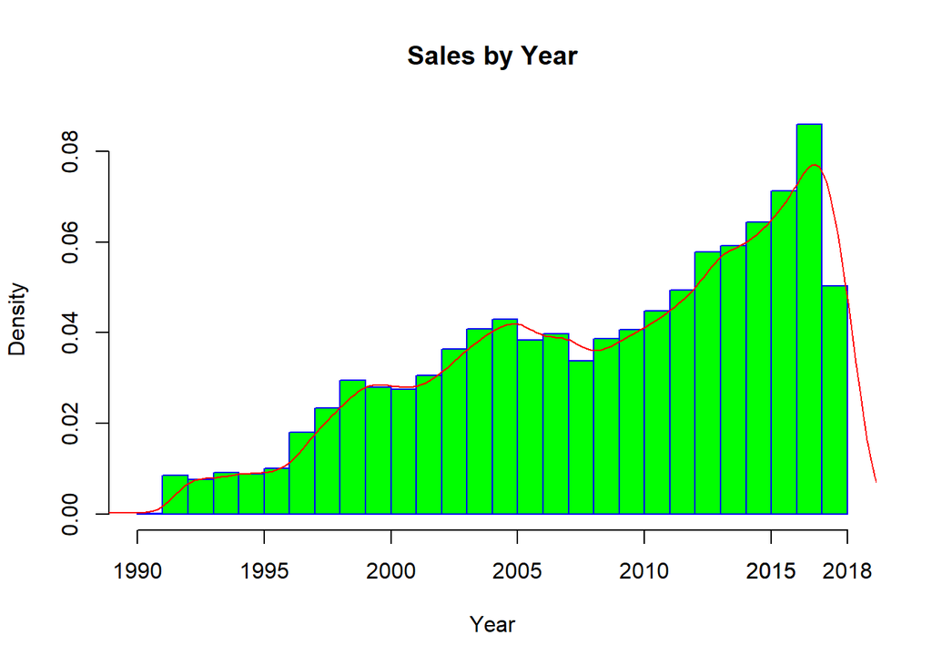

```r
house.price$SALEDATE <- substr(house.price$SALEDATE, 0, 10)
house.price$SALEDATE <- as.Date(house.price$SALEDATE)

sale.year <- as.numeric(substr(house.price[, "SALEDATE"], 0, 4))
sale.year <- sale.year[!is.na(sale.year)]
hist(sale.year,
     breaks = c(-Inf, seq(1990, 2018, 1)),
     xlim = c(1990, 2018),
     main = "Sales by Year",
     xlab = "Year",
     border = 'blue', col = 'green',
     prob = T)
axis(side = 1, at = c(2015, 2018))
lines(density(sale.year), col = 'red')
```

There are more observations as it gets closer to the recent. This is good news as the survey seeks for the recent trend. This figure also shows a random pattern that house markets are active one season and become loose next season. It will be very difficult to make use of old data except for finding a historical pattern. The data starting from 2016 still covers 20% of all.

```r
quantile(sale.year, probs = seq(0, 1, 0.1))
```

```
##   0%  10%  20%  30%  40%  50%  60%  70%  80%  90% 100%
## 1947 1999 2002 2005 2007 2010 2012 2014 2016 2017 2018
```

```r
# drop sales made before 2016.01.01.
house.price <- subset(house.price, SALEDATE > as.Date("2015-12-31"))
```

### **Dependent Variable: *Price***

It would be reasonable to investigate house prices as these are what to be analyzed and predicted. Looking into the dependent variable would help with having an idea for independent variables too since the goal is to define their relationship.

```r
# drop rows with price as NA
house.price <- house.price[complete.cases(house.price[ , "PRICE"]), ]
```

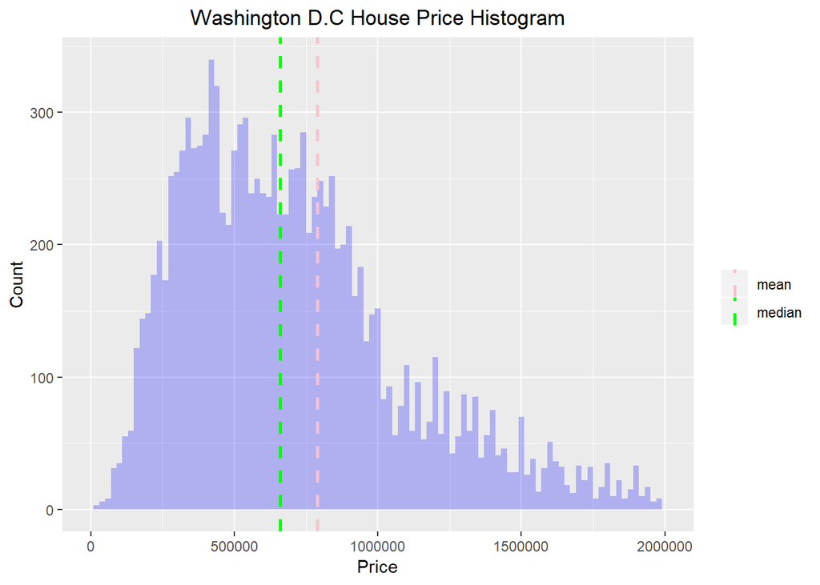

```r
# histogram independent variable "Price"
ggplot(house.price, aes(x = PRICE)) +
  geom_histogram(binwidth = 20000,
                 fill = "blue",
                 alpha = .25) +
  labs(title = "Washington D.C House Price Histogram") +
  labs(x = "Price", y = "Count") +
  theme(plot.title = element_text(hjust = 0.5)) +
  xlim(c(0, 2000000)) +
  geom_vline(aes(xintercept = mean(PRICE), color = "mean"),
             linetype = "dashed", size = 1) +
  geom_vline(aes(xintercept = median(PRICE), color = "median"),
             linetype = "dashed", size = 1) +
  scale_color_manual(name = "", values = c(mean = "pink", median = "green"))
```

From both the shape and statistics, house price data are skewed. Most of the houses are in a certain range with a few expensive houses. However, transformation might be carefully considered, not just with the histogram.

```r
summary(house.price$PRICE)
```

```
##     Min.  1st Qu.   Median     Mean  3rd Qu.     Max.
##       10   418000   659266   789970   940000 25100000
```

### **On the Map**

One of the best ways to have a sense of data is visualization. Since the data could be fundamentally geographic, it would be a good attemp to visualize prices on the Washington D.C. map. On the map, the darker dots are the more expensive.

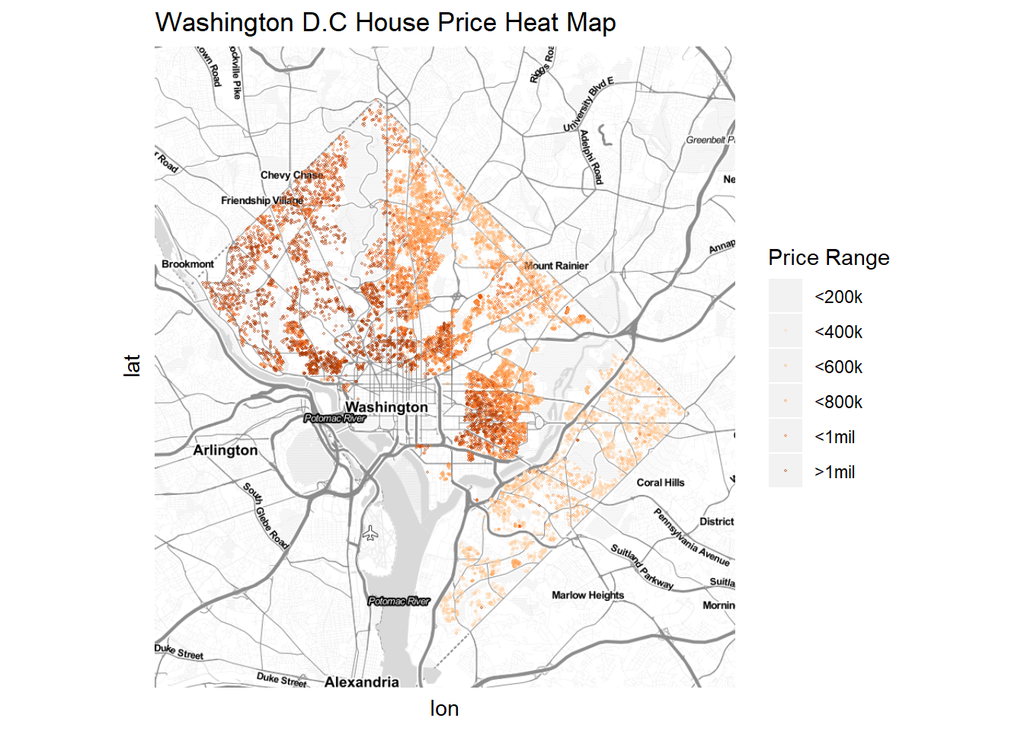

```r
ggmap(dc_map) +
  geom_point(data = house.price,
             aes(LONGITUDE, LATITUDE,
                 color = cut(PRICE, price_group)),
             size = 0.3, alpha = 0.3) +
  labs(title = "Washington D.C House Price Heat Map") +
  theme(axis.text.x = element_blank(),
        axis.ticks.x = element_blank(),
        axis.text.y = element_blank(),
        axis.ticks.y = element_blank()) +
  scale_color_brewer(palette = "Oranges",
                     name = "Price Range",
                     labels = price_label)
```

The areas with no dots are mostly hills or other types where a house can’t be build on. Certainly, there are some expensive areas and the other way around. Washington D.C. is consisted of 8 wards of which ward 2 and 3 are where dots are darker while the rest are brighter. But ward 6 in the middle is a bit ambiguous to tell because its left is dark but the right is not. Ward is actually one of the columns so it will be studied by each ward.

### **Handle Outliers**

As shown on the histogram, there are a series of very expensive houses. These probably would interfere with modeling, thus, must be handled before moving forward. Outliers here are defined as observations over or less than $Interquantile\ Range\times1.5$. The lower cut-off, however, is negative leaving only the expensive houses as outliers.

```r
lowerq <- quantile(house.price$PRICE)[2]
upperq <- quantile(house.price$PRICE)[4]
iqr <- upperq - lowerq
lower.threshold <- lowerq - (iqr*1.5)
upper.threshold <- upperq + (iqr*1.5)

cat("Lower Outlier Threshold:", lower.threshold,
    "\nUpper Outlier Threshold:", upper.threshold)
```

```
## Lower Outlier Threshold: -365000
## Upper Outlier Threshold: 1723000
```

```r
house.price <- house.price[house.price$PRICE < upper.threshold, ]
```

### **Preprocessing: *Drop Variables***

As explained, some variables do not have meaningful or unique information. Although a variable has its own information, it could still be not useful if some other variable can replace it or have better information. The data set has so many geographical data which come in different forms but have a common ground. Before taking care of that, *NA* values should be controlled.

```r
# no longer needed
house.price <- select(house.price, -c("SOURCE", "SALEDATE"))
```

```r
# count NA for each variable
na_count <- sapply(house.price, function(y) {
    sum(length(which(is.na(y))))
  })

# all the variables with NA's
na_count <- na_count[na_count != 0]
# variable and the number of NA's
print(na_count)
```

```
##                AYB            YR_RMDL            STORIES
##                 19               4861                 19
##           KITCHENS          CMPLX_NUM         LIVING_GBA
##                  1              12041              12041
##        FULLADDRESS       NATIONALGRID ASSESSMENT_SUBNBHD
##                119                119               1439
##       CENSUS_BLOCK           QUADRANT
##                119                 25
```

“LIVING GBA” and “CMPLX NUM” are completely empty, suggesting that they are typical data of condominiums which are excluded at the beggining. Therefore, these two should simply be dropped. “YR RMDL” have about one third empty and this must be because not all the houses have been remodeled. While dropping is not the best, the solution for this would be type conversion so that it is either a yes or a no as to whether remodeled or not. The rest are mostly geographical columns. While neighborhood is accepted as a good indicator for house prices, there are 57 different of them to make too many levels. As the final model will be a linear model, having too many category is susceptible to overfitting and losing general trends. Most importantly ward seems to be very useful as confirmed on the map.

```r
# drop empty variables
house.price <- select(house.price, -c("CMPLX_NUM", "LIVING_GBA"))

# transform YR_RMDL by encoding into Yes or No
house.price$RMDL <- ifelse(is.na(house.price$YR_RMDL), "N", "Y")
house.price$RMDL <- as.factor(house.price$RMDL)

# drop geographical variables except for WARD
house.price <- select(house.price, -c("ZIPCODE", "USECODE", "SQUARE", "NATIONALGRID",
                                      "ASSESSMENT_NBHD", "ASSESSMENT_SUBNBHD",
                                      "CENSUS_BLOCK", "CENSUS_TRACT",
                                      "QUADRANT", "FULLADDRESS",
                                      "LONGITUDE", "LATITUDE"))
```

```r
# fine tuning
cat("GIS values:")
```

```
## GIS values:
```

```r
print(levels(house.price$GIS_LAST_MOD_DTTM))
```

```
## [1] "2018-07-22 18:01:38" "2018-07-22 18:01:43"
```

```r
house.price <- select(house.price, -c("GIS_LAST_MOD_DTTM", "YR_RMDL"))

# drop small number of NA's (AYB, STORIES...)
house.price <- house.price[complete.cases(house.price), ]
```

## **Data Analysis**

This part pays attention to relationships among variables. Separate analysis will be conducted by data type, numerical and categorical, and then another for both of them together. For numerical types, correlation matrix will be drawn not only to find relationship with dependent variable but also to catch multicollinearity patterns. For categorical types, box plots will be used to see whether each category has an ability to divide house prices and what values are useful if so. Box plot also can help to decide whether to reduce number of values in a category.

### **Correlation Matrix**

```r
numeric_cols <- names(select_if(house.price, is.numeric))
print(numeric_cols)
```

```
##  [1] "BATHRM"     "HF_BATHRM"  "NUM_UNITS"  "ROOMS"      "BEDRM"
##  [6] "AYB"        "EYB"        "STORIES"    "PRICE"      "SALE_NUM"
## [11] "GBA"        "BLDG_NUM"   "KITCHENS"   "FIREPLACES" "LANDAREA"
```

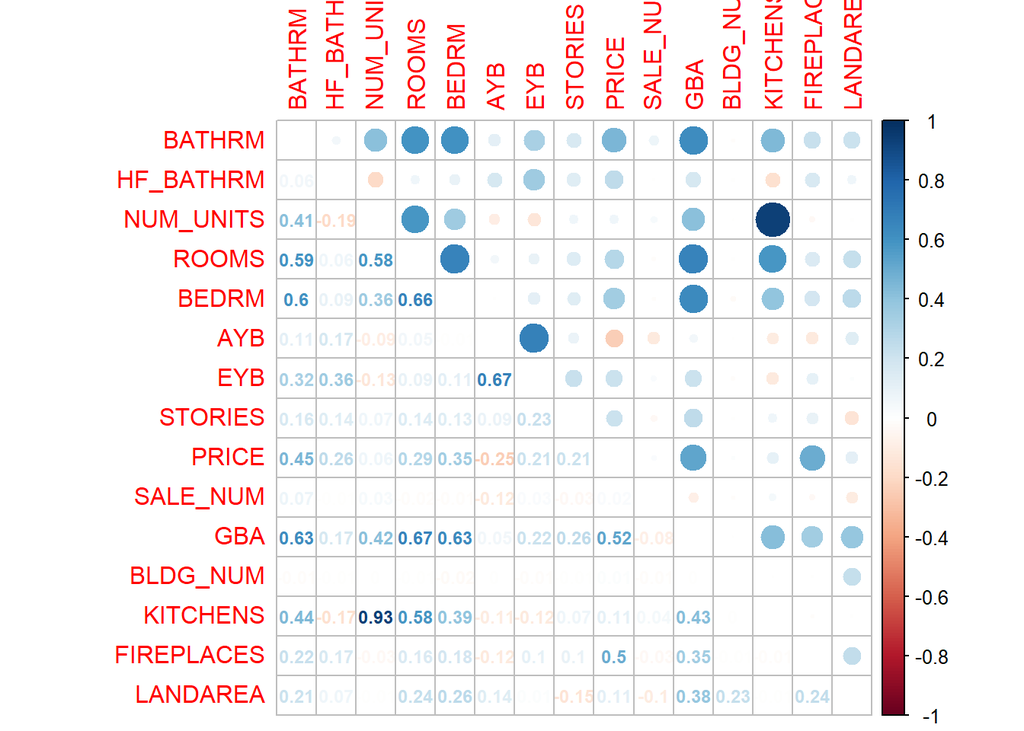

```r
corr <- cor(house.price[, numeric_cols])
corrplot.mixed(corr, number.cex = .75, tl.pos = "lt")
```

“SALE NUM” and some others have no relationship with any others, thus, they can be easily gone. “PRICE” has a decent relationship with the rest, especially with “GBA” and room-related variables. However, there are multicollinearity issues such as “NUM UNITS” and “KITCHENS”. These should be handled first, and then another matrix should be drawn.

```r
# drop unrelated variables
house.price <- subset(house.price, select = -c(SALE_NUM, BLDG_NUM, NUM_UNITS,
                                               KITCHENS, LANDAREA))
```

```r
# test for multicollinearity of numerical variables
VIF.model <- lm(PRICE ~ BATHRM + HF_BATHRM + ROOMS + BEDRM +
                  AYB + EYB + STORIES + GBA + FIREPLACES,
                data = house.price)
cat("[VIF with All]\n")
```

```
## [VIF with All]
```

```r
print(vif(VIF.model))
```

```
##     BATHRM  HF_BATHRM      ROOMS      BEDRM        AYB        EYB
##     2.2109     1.2203     2.3428     2.1811     2.0363     2.5310
##    STORIES        GBA FIREPLACES
##     1.1156     2.5999     1.2261
```

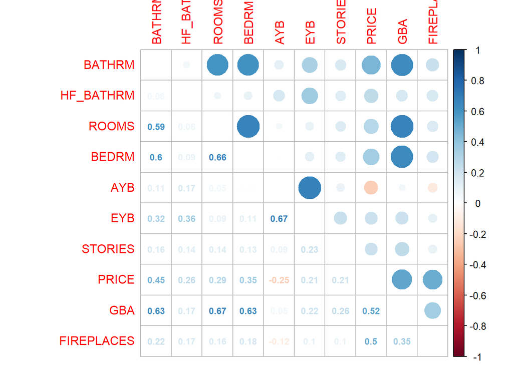

```r
# final correaltion table
numeric_cols <- names(select_if(house.price, is.numeric))
corr <- cor(house.price[, numeric_cols])
corrplot.mixed(corr, number.cex = .75, tl.pos = "lt")
```

There are still multicollinearity problems, but these are under the serious level and will be handled again during modeling. Again, house prices seem to have high correlations with area-related variables, which comes no surprise. Still, quality factors such as year built or fire place would mildly affect house prices. Although there are higher numbers on the matrix, “PRICE” has some relationships uniformly with the variables when the same can’t be applied to other variables.

### **Scatter Plot**

Scatter plot is basic to find a pattern between two numerical variables. Either going up or down, a slope means a relationship. When units are too different among variables, normalization could be considered or it might mislead interpretation if they are put together. Variables related with rooms are in the similar range, therefore, they are put together first. Next, variables related with years and the rest are drawn on the same pane.

```r
house.price_scatter <- function(var, x_start, x_lim) {
  ggplot(house.price, aes_string(var, "PRICE", fill = var)) +
    geom_point(color = "darkgreen", shape = 1, alpha = 0.1,
               size = 0.2, position = "jitter") +
    geom_smooth(span = 5, method = lm) +
    ggtitle(toString(var)) + xlab("") +
    theme(legend.position="none") +
    scale_x_continuous(limits = c(x_start, x_lim)) +
    scale_y_continuous(limits = c(0, 1750000),
                       breaks = seq(0, 1750000, 250000))
}
```

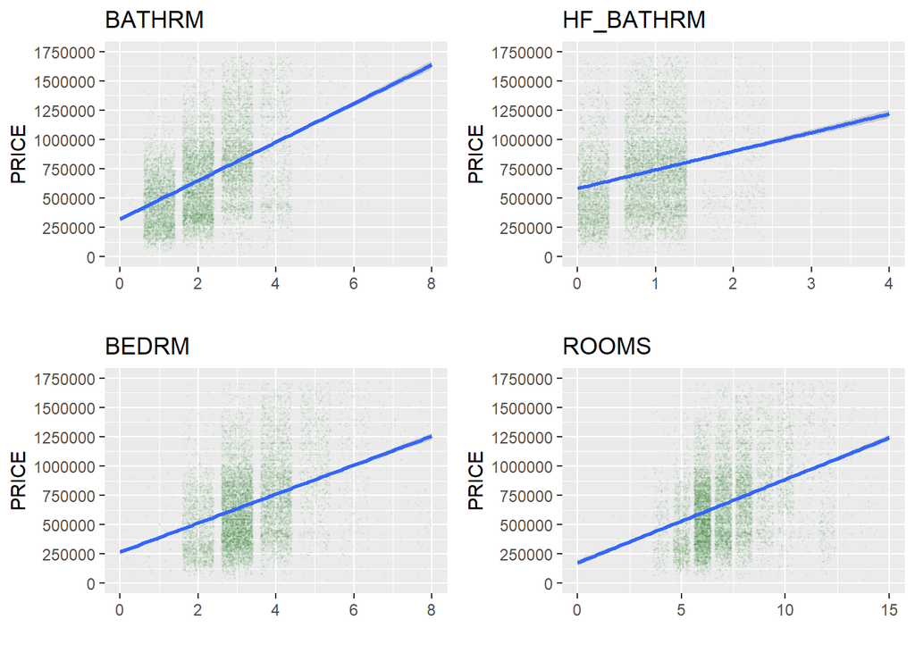

```r
BATHRM <- house.price_scatter("BATHRM", 0, 8)
HF_BATHRM <- house.price_scatter("HF_BATHRM", 0, 4)
BEDRM <- house.price_scatter("BEDRM", 0, 8)
ROOMS <- house.price_scatter("ROOMS", 0, 15)

grid.arrange(BATHRM, HF_BATHRM, BEDRM, ROOMS,
             ncol = 2, nrow = 2)
```

It seems like there is a strong pattern going up. It is very natural that a house price increases as it has more rooms. One surprising thing is that number of bathrooms has a sharper slope than number of bedrooms. Indeed, it is often seen that a 2-bedroom/2-bathroom house is more expensive than a 3-bedroom/1-bathroom house. Another thing to note is that it seems like prices become variable more widely as there are more rooms. For example, the price range of 3 to 4 rooms is much smaller than the price range of 7 to 8 rooms. Since room variables will play a significant role, [heteroscedasticity](http://www.statsmakemecry.com/smmctheblog/confusing-stats-terms-explained-heteroscedasticity-heteroske.html) is expected to happen, and this will be cared later.

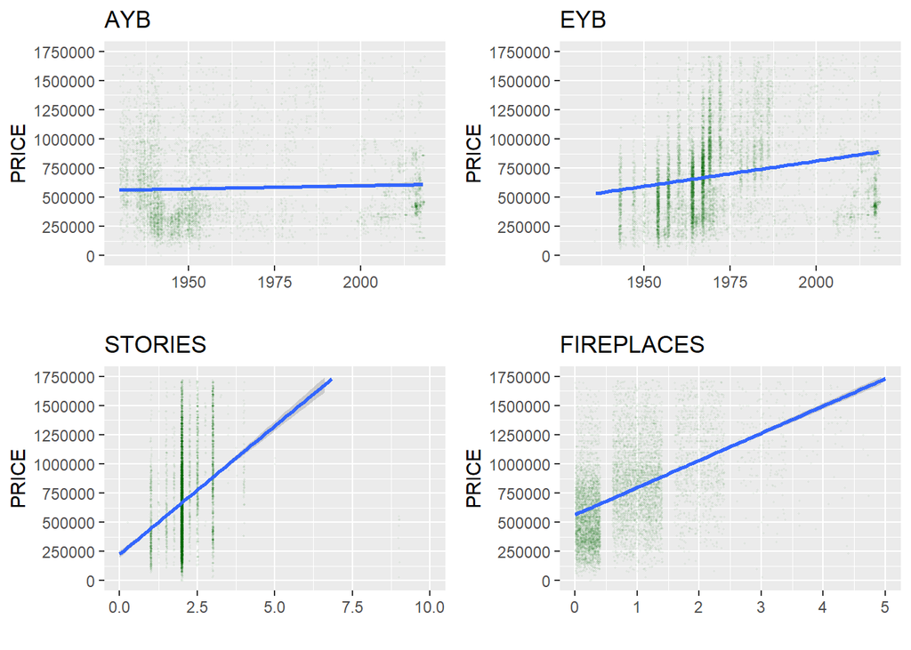

```r
AYB <- house.price_scatter("AYB", 1930, 2020)
EYB <- house.price_scatter("EYB", 1930, 2020)
STORIES <- house.price_scatter("STORIES", 0, 10)
FIREPLACES <- house.price_scatter("FIREPLACES", 0, 5)


grid.arrange(AYB, EYB, STORIES, FIREPLACES,
             ncol = 2, nrow = 2)
```

Variables related with years show a rough pattern. “EYB” has some slope which is affected by data after 2000. These are what must be heavily affected by contingent market trends, not by typical features. Although “STORIES” has a good sharp slope, they are mostly 2 to 3 stories with large variances. “FIREPLACE” has a decent movement within 0 to 1 range.

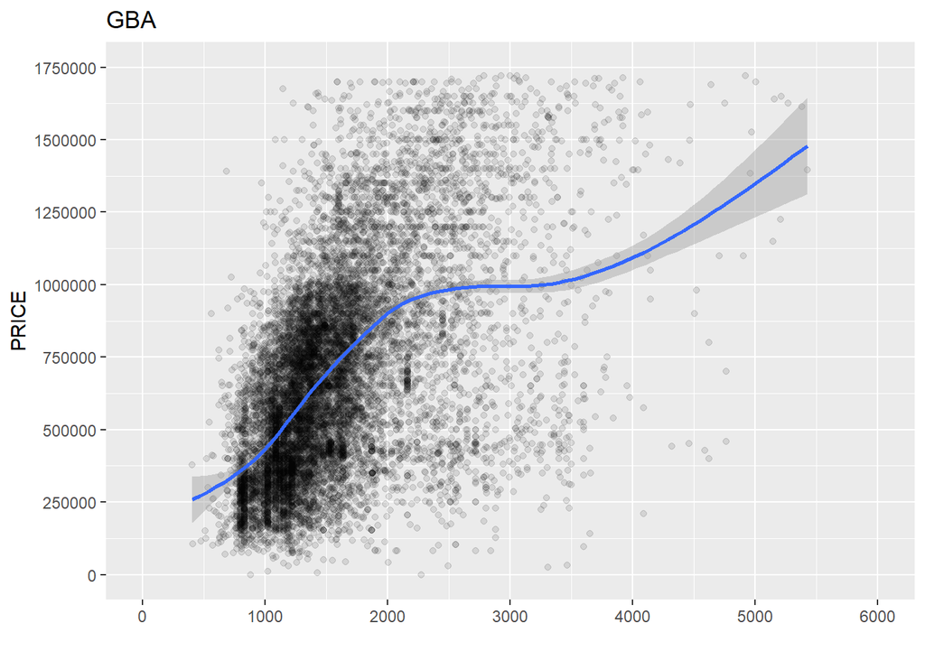

```r
ggplot(house.price, aes(x = GBA, y = PRICE)) +
  geom_point(alpha = 0.1) +
  geom_smooth() +
  ggtitle("GBA") + xlab("") +
  scale_x_continuous(limits = c(0, 6000),
                     breaks = seq(0, 6000, 1000)) +
  scale_y_continuous(limits = c(0, 1750000),
                     breaks = seq(0, 1750000, 250000))
```

“GBA” has totally different unit, square feet, so is drawn solely. Also, this appeals the heteroscedasticity issue very clearly. As a house gets bigger, its price could be in any range. This can be understood that houses with 1-bedroom, for instance, should be in a small price range because a new house in downtown is still just 1-bedroom. But houses with 4-bedroom could be over million dollars or an old out-of-maintenance house on auction.

### **Transformation: *Box-Cox***

Now that the variance issue is found, it is time to fix it. For the last check, Breusch-Pagan test can be conducted on a linear model. The test runs with null hypothesis that the variances are uniform over values. As seen below, the results are enough to reject the null hypothesis and claim the variance issues.

```r
# linear model with numerical variables
Numeric.lm <- lm(PRICE ~ BATHRM + HF_BATHRM + BEDRM + ROOMS +
                   AYB + EYB + STORIES + FIREPLACES + GBA,
                 data = house.price)

# constant variance tests
print(bptest(Numeric.lm))
```

```
##
##  studentized Breusch-Pagan test
##
## data:  Numeric.lm
## BP = 1007.1, df = 9, p-value < 2.2e-16
```

```r
print(ncvTest(Numeric.lm))
```

```
## Non-constant Variance Score Test
## Variance formula: ~ fitted.values
## Chisquare = 1220.9, Df = 1, p = < 2.22e-16
```

Box-Cox suggests how to transform the data. The lambda is the core concept of the method that would be iterated between a certain range. Lambda nearing 0.5 indicates square root transformation for prices.

```r
# box-cox
bc <- boxCox(Numeric.lm)
```

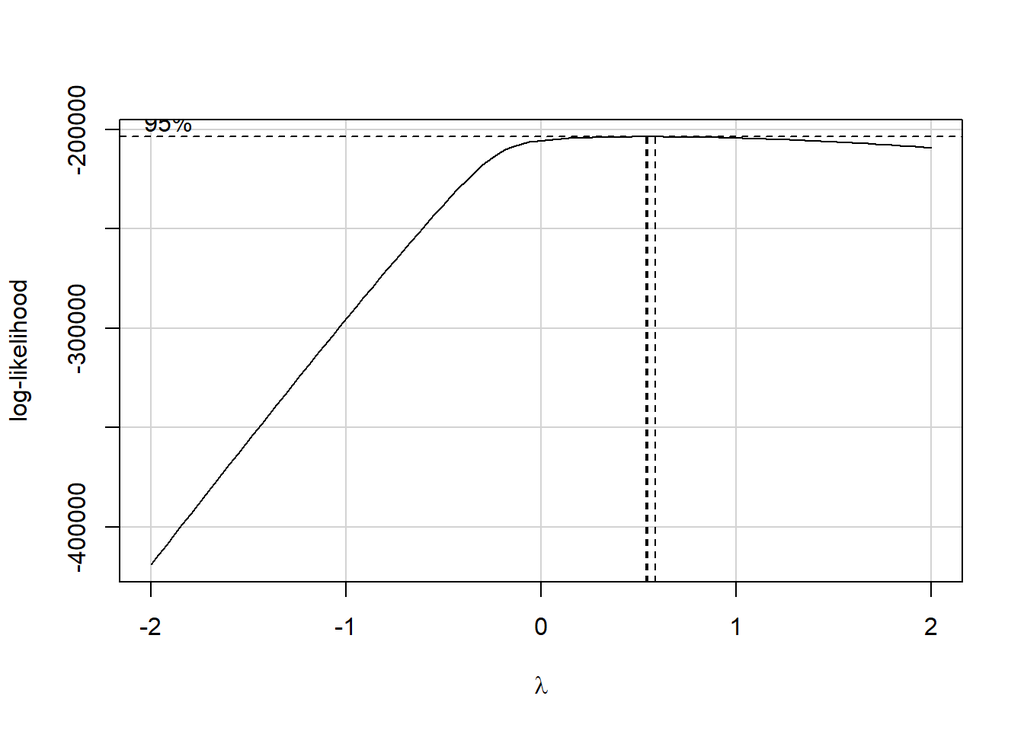

```r
lambda <- bc$x[which.max(bc$y)]
cat("Lambda for Transformation:", lambda)
```

```
## Lambda for Transformation: 0.5454545
```

After transformation, the distribution becomes better than the initial one. The dotted line is the normal curve for comparison. Despite being not perfectly matched, at least the skewness is fixed as the mean median are aligned.

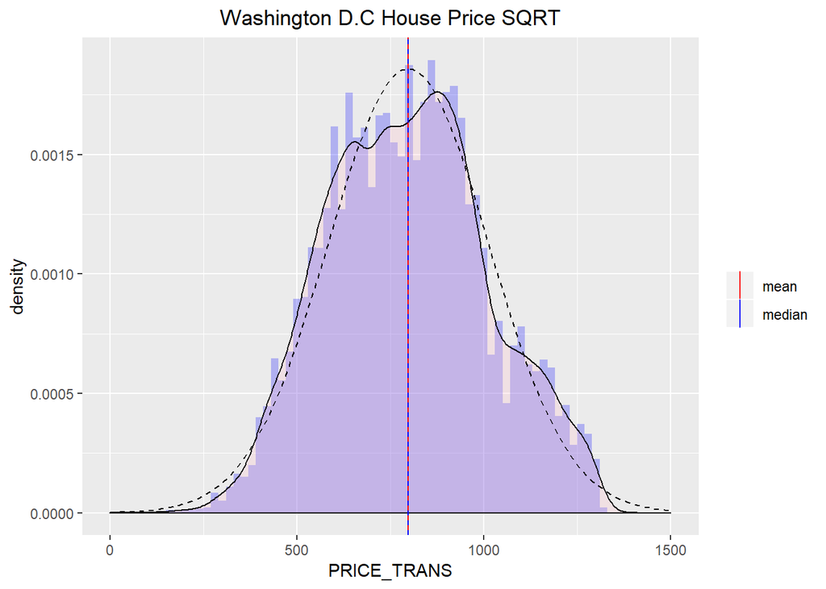

```r
# transformation to sqrt
house.price$PRICE_TRANS <- sqrt(house.price$PRICE)
house.price <- select(house.price, -PRICE)

# price-sqrt histogram
ggplot(house.price, aes(x = PRICE_TRANS)) +
  geom_histogram(aes(y = ..density..),
                 binwidth = 20, fill = "blue", alpha = 0.25) +
  geom_density(fill = "pink", alpha = 0.25) +
  labs(title = "Washington D.C House Price SQRT") +
  theme(plot.title = element_text(hjust = 0.5)) +
  geom_vline(aes(xintercept = mean(PRICE_TRANS), color = "mean"), size = 0.5) +
  geom_vline(aes(xintercept = median(PRICE_TRANS), color = "median"),
             linetype = "dashed", size = 0.5) +
  scale_x_continuous(limits = c(0, 1500)) +
  scale_color_manual(name = "", values = c(mean = "red", median = "blue")) +
  stat_function(fun = dnorm, args = list(
    mean = mean(house.price$PRICE_TRANS), sd = sd(house.price$PRICE_TRANS)),
    linetype = "dashed")
```

Although the correlations decreased a bit, it is more important to abide by the assumption of variance and normality, thus, the transformation is necessary.

```r
# final correlations with PRICE_TRANS
X_num <- names(select_if(house.price, is.numeric))
X_num <- X_num[X_num != "PRICE_TRANS"]
cat("[Price SQRT vs. X Variables Correlation]\n")
```

```
## [Price SQRT vs. X Variables Correlation]
```

```r
kable(cor(house.price[, X_num], house.price$PRICE_TRANS)) %>%
  kable_styling(bootstrap_options = c("striped", "hover"), full_width = F)
```

| BATHRM | 0.4432783 |
| --- | --- |
| HF_BATHRM | 0.2619754 |
| ROOMS | 0.2784958 |
| BEDRM | 0.3369135 |
| AYB | -0.2574367 |
| EYB | 0.2098391 |
| STORIES | 0.2011221 |
| GBA | 0.4984254 |
| FIREPLACES | 0.4796368 |

### **Box Plot**

Box plot is helpful to see if a categorical variable can divide dependent variables into groups. The data set has several categorical variables from building materials, functions, quality, to area. Some has too many different values available, some has unbalanced values, and another has its own issue. The following is general remedy for these kind of problems, some of which will be used for the project.

- No effect: Drop the category
- Too many values: Group them by similarity
- Unbalanced values: Keep the major value and merge all the minor values
- Specific order: Label values with numbers
- More of numerical type: Replace each value with a certain number like median

```r
categorical_cols <- names(select_if(house.price, is.factor))
print(categorical_cols)
```

```
##  [1] "HEAT"      "AC"        "QUALIFIED" "STYLE"     "STRUCT"
##  [6] "GRADE"     "CNDTN"     "EXTWALL"   "ROOF"      "INTWALL"
## [11] "WARD"      "RMDL"
```

```r
# number of unique values in each categorical variable
str(apply(house.price[, categorical_cols], 2, function(x) unique(x)))
```

```
## List of 12
##  $ HEAT     : chr [1:14] "Warm Cool" "Hot Water Rad" "Forced Air" "Ht Pump" ...
##  $ AC       : chr [1:3] "Y" "N" "0"
##  $ QUALIFIED: chr [1:2] "Q" "U"
##  $ STYLE    : chr [1:13] "2 Story" "3 Story" "2.5 Story Fin" "4 Story" ...
##  $ STRUCT   : chr [1:8] "Row Inside" "Semi-Detached" "Multi" "Row End" ...
##  $ GRADE    : chr [1:9] "Above Average" "Very Good" "Average" "Excellent" ...
##  $ CNDTN    : chr [1:7] "Very Good" "Excellent" "Good" "Average" ...
##  $ EXTWALL  : chr [1:21] "Common Brick" "Stone" "Stucco" "Brick/Stone" ...
##  $ ROOF     : chr [1:12] "Built Up" "Metal- Sms" "Slate" "Comp Shingle" ...
##  $ INTWALL  : chr [1:11] "Hardwood" "Hardwood/Carp" "Carpet" "Wood Floor" ...
##  $ WARD     : chr [1:8] "Ward 2" "Ward 1" "Ward 6" "Ward 5" ...
##  $ RMDL     : chr [1:2] "Y" "N"
```

```r
# fix '0' values in AC
cat("Number of '0's in AC:", pull(count(house.price[house.price$AC == '0', ])))
```

```
## Number of '0's in AC: 6
```

```r
house.price[house.price$AC == '0', 'AC'] <- "N"
```

```r
house.price_boxplot <- function(var, x.angle) {
  ggplot(house.price, aes_string(var, "PRICE_TRANS", fill = var)) +
    geom_boxplot(outlier.colour = "black",
                 outlier.shape = 16,
                 outlier.size = 1) +
    geom_hline(aes(yintercept = median(PRICE_TRANS)),
               color = 'gray', linetype = "dashed", size = 0.5) +
    ggtitle(toString(var)) + xlab("") +
    theme(legend.position="none",
          axis.text.x = element_text(angle = x.angle, hjust = 1))
}
```

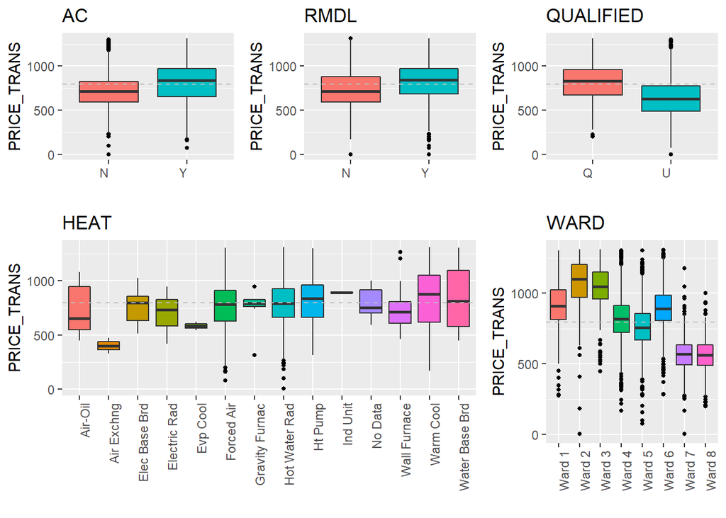

```r
lay <- rbind(c(1, 2, 3),
             c(4, 4, 5))
grid.arrange(grobs = list(house.price_boxplot("AC", 0),
                          house.price_boxplot("RMDL", 0),
                          house.price_boxplot("QUALIFIED", 0),
                          house.price_boxplot("HEAT", 90),
                          house.price_boxplot("WARD", 90)),
             heights = c(0.4, 0.6),
             layout_matrix = lay)
```

“AC”, “RMDL”, and “QUALIFIED” have two classes. Among them, “QUALIFIED” seems to do the best job to divide expensive houses and cheap houses, of course, qualified houses value more and the same goes for remodeled houses with air conditioner equipped. “HEAT” is a bit confusing in that most of values are around the median price (dotted line). Though there are some values “Air Exchng” or “Evp Cool”, their counts do not seem to be enough to make a contribution. For that reason, “HEAT” should rather be dropped. “WARD” looks like it will be beneficial as each ward are ranged properly and located differently. Some issue here is that they have many outliers and ward 7 and 8 are almost identical. Nonetheless, this looks good enough useful when working with numerical variables.

```r
# drop HEAT
print(summary(house.price$HEAT))
```

```
##        Air-Oil     Air Exchng  Elec Base Brd   Electric Rad       Evp Cool
##             11              2              8              6              2
##     Forced Air Gravity Furnac  Hot Water Rad        Ht Pump       Ind Unit
##           5450              8           3957            189              1
##        No Data   Wall Furnace      Warm Cool Water Base Brd
##              7             22           2319             20
```

```r
house.price <- select(house.price, -HEAT)

# reduce wards to three types
# house.price$WARD <- ifelse(house.price$WARD %in% c('Ward 2', 'Ward 3'),
#                            'Ward 2/3', as.character(house.price$WARD))
# house.price$WARD <- ifelse(house.price$WARD %in% c('Ward 7', 'Ward 8'),
#                            'Ward 7/8', as.character(house.price$WARD))
# house.price$WARD <- ifelse(!house.price$WARD %in% c('Ward 2/3', 'Ward 7/8'),
#                            'Ward 3/4/5/6', as.character(house.price$WARD))
```

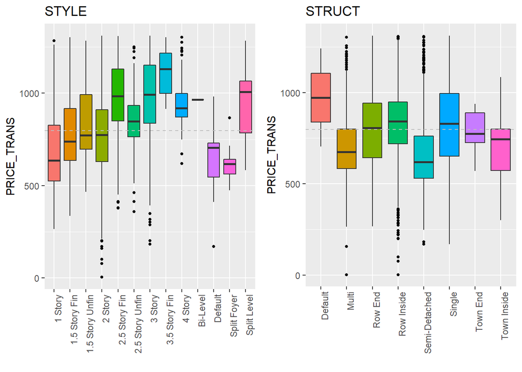

```r
grid.arrange(house.price_boxplot("STYLE", 90),
             house.price_boxplot("STRUCT", 90),
             ncol = 2)
```

The values in “STYLE” are basically stories. Since “STORIES” variable already exists, this can be removed. Also, almost all of them (9557 count) are “2 Story” making it severely unbalanced. “STRUCT” looks like it could do some job to find cheap houses by the value “Multi” or “Semi-Detached”.

```r
# Style is same as Story, Struct is ambiguous
print(summary(house.price$STYLE))
```

```
##         1 Story   1.5 Story Fin 1.5 Story Unfin         2 Story
##             461             245              16            9557
##   2.5 Story Fin 2.5 Story Unfin         3 Story   3.5 Story Fin
##             633              63             918              14
## 3.5 Story Unfin         4 Story   4.5 Story Fin 4.5 Story Unfin
##               0              52               0               0
##        Bi-Level         Default    Outbuildings     Split Foyer
##               1               8               0              18
##     Split Level          Vacant
##              16               0
```

```r
house.price <- select(house.price, -STYLE)

print(summary(house.price$STRUCT))
```

```
##       Default         Multi       Row End    Row Inside Semi-Detached
##             2           625          1432          5046          1829
##        Single      Town End   Town Inside   Vacant Land
##          3019            12            37             0
```

```r
house.price$STRUCT <- ifelse(house.price$STRUCT %in%
                          c("Multi", "Semi-Detached", "Town Inside"),
                          "Cheap", "Expensive")
```

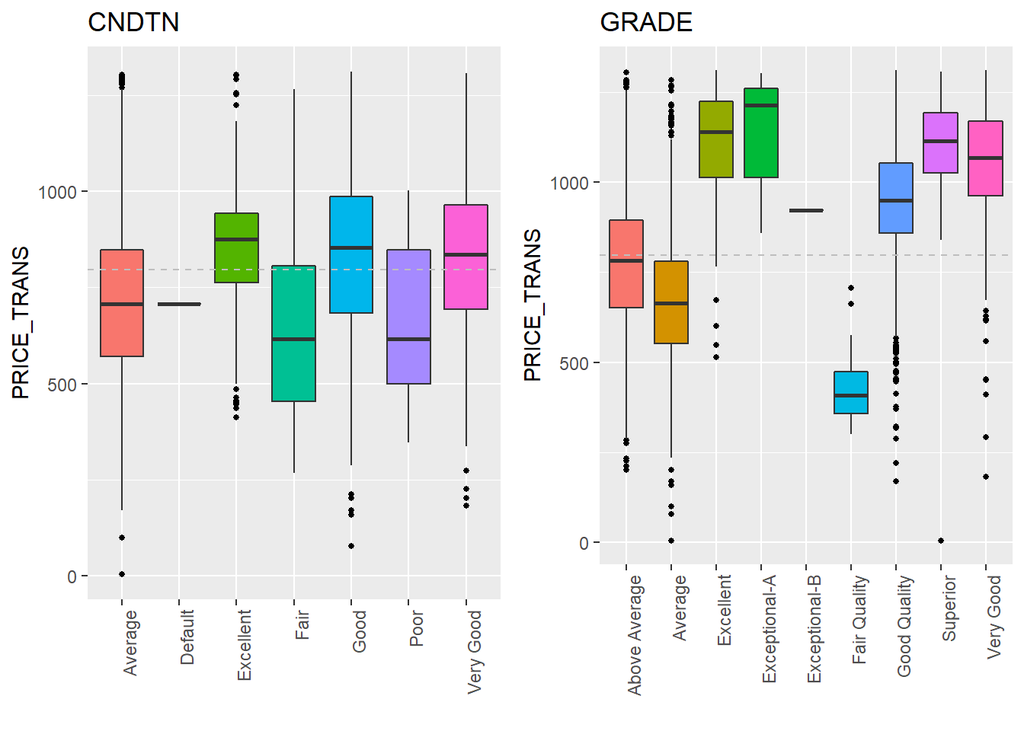

```r
grid.arrange(house.price_boxplot("CNDTN", 90),
             house.price_boxplot("GRADE", 90),
             ncol = 2)
```

“CDNTN” and “GRADE” show a similar pattern that average or fair houses are cheaper. These houses are under the median line and the rest are above very clearly. So, these several values can be grouped into two. This way, the values in “CDNTN” become balanced too. The values in “GRADE”, however, are not quite two group dividable as there are unignorable discrepancies among similair values. This will be further investigated.

```r
# cat("[Grade counts]\n")
# cat("\n[Condition counts]\n")

# Grade: above-avg / avg / fair vs. rest
print(summary(house.price$GRADE))
```

```
## Above Average       Average     Excellent Exceptional-A Exceptional-B
##          3741          4675           229            14             1
## Exceptional-C Exceptional-D  Fair Quality  Good Quality   Low Quality
##             0             0            22          2313             0
##       No Data      Superior     Very Good
##             0           164           843
```

```r
# house.price$GRADE <- ifelse(house.price$GRADE %in%
#                         c("Above Average", "Average", "Fair Quality"),
#                         "Average", "High")

# Condition: avg / fair / poor vs. rest -> try to take median to GRADE_MEDIAN_PRICE
print(summary(house.price$CNDTN))
```

```
##   Average   Default Excellent      Fair      Good      Poor Very Good
##      4179         1       236       117      5392        28      2049
```

```r
house.price$CNDTN <- ifelse(house.price$CNDTN %in%
                        c("Average", "Fair", "Poor"), "Bad", "Good")
```

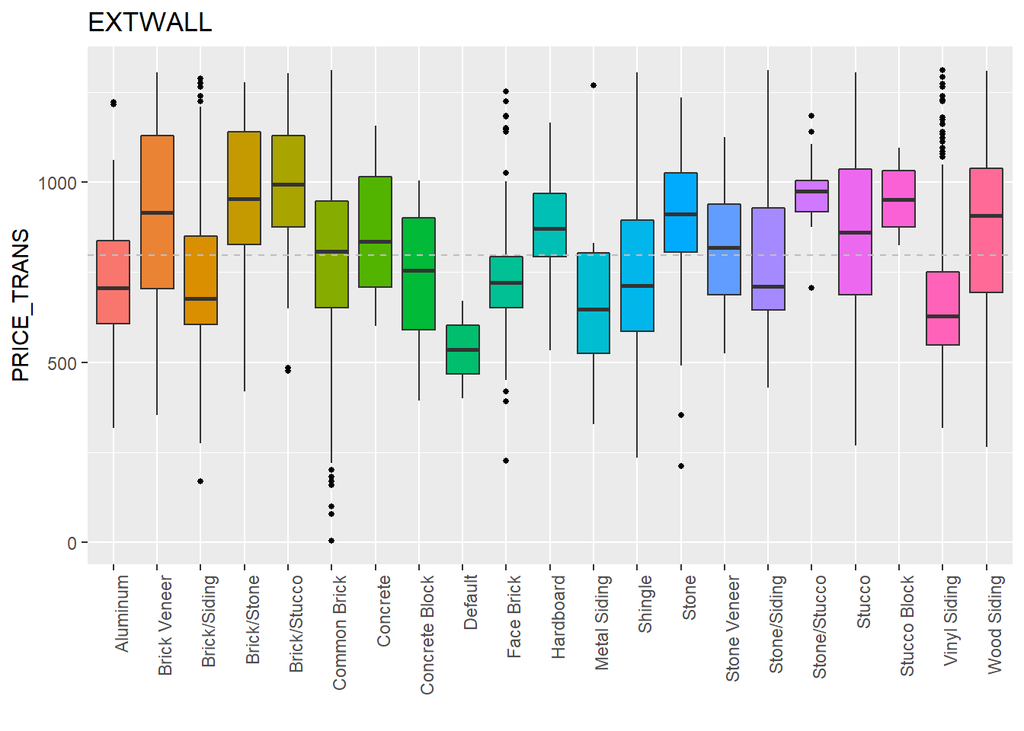

```r
house.price_boxplot("EXTWALL", 90)
```

There are just too many values in “EXTWALL”, thus, it is inevitable to group them. With some extra research about exterior materials, they can be grouped into “Premium” or “Normal”.

[brick vs. wood](http://www.massrealty.com/articles/brick-homes-vs-wood-homes) [stucco](https://en.wikipedia.org/wiki/Stucco)

```r
# cat("[Exterior wall counts]\n")
print(summary(house.price$EXTWALL))
```

```
##          Adobe       Aluminum   Brick Veneer   Brick/Siding    Brick/Stone
##              0            100            129            779             70
##   Brick/Stucco   Common Brick       Concrete Concrete Block        Default
##             65           9025             12              7              2
##     Face Brick      Hardboard   Metal Siding        Plywood     Rustic Log
##            123             18              7              0              0
##        Shingle       SPlaster          Stone   Stone Veneer   Stone/Siding
##            121              0             57             35             43
##   Stone/Stucco         Stucco   Stucco Block   Vinyl Siding    Wood Siding
##             18            286              4            661            440
```

```r
house.price$EXTWALL <- ifelse(house.price$EXTWALL %in%
                          c("Brick Veneer", "Brick/Stone", "Brick/Stucco", "Hardboard",
                            "Stone", "Stone/Stucco", "Stucco Block", "Wood Siding"),
                          "Premium", "Normal")
```

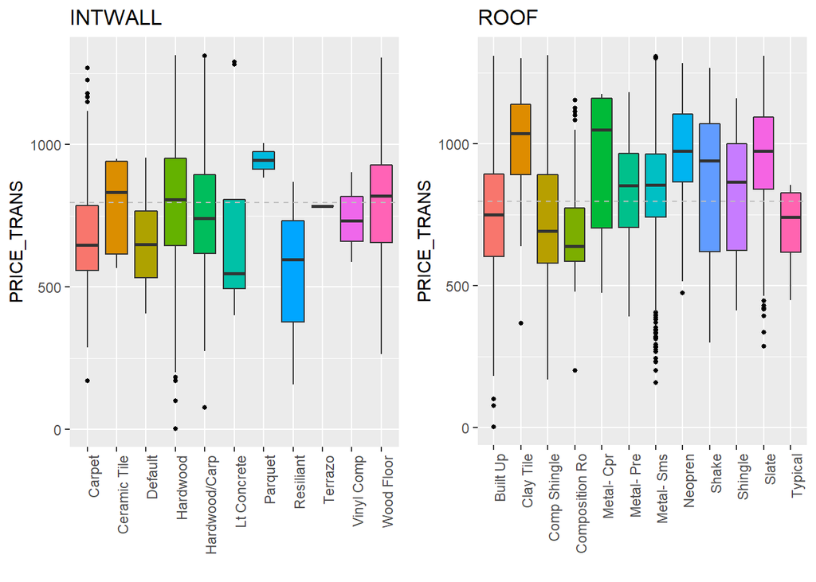

```r
grid.arrange(house.price_boxplot("INTWALL", 90),
             house.price_boxplot("ROOF", 90),
             ncol = 2)
```

“INTWALL” might have a chance to be grouped, but it should be dropped because of unbalanced issue. There are 9466 houses with “Hardwood” interior type, which are almost entire cases. As for “ROOF”, there are four types that are obviously over the median line, and these can go together.

```r
# drop Interior
print(summary(house.price$INTWALL))
```

```
##        Carpet  Ceramic Tile       Default      Hardwood Hardwood/Carp
##           300             6             6          9466          1419
##   Lt Concrete       Parquet     Resiliant       Terrazo    Vinyl Comp
##             8             2             3             1             3
##   Vinyl Sheet    Wood Floor
##             0           788
```

```r
house.price <- select(house.price, -INTWALL)

# Roof: cheap vs. expensive
# cat("[Roof counts]\n")
print(summary(house.price$ROOF))
```

```
##       Built Up      Clay Tile   Comp Shingle Composition Ro       Concrete
##           3869             47           3464             24              0
##  Concrete Tile     Metal- Cpr     Metal- Pre     Metal- Sms        Neopren
##              0              5             32           3460            121
##          Shake        Shingle          Slate        Typical    Water Proof
##             65             43            853             19              0
##       Wood- FS
##              0
```

```r
house.price$ROOF <- ifelse(house.price$ROOF %in%
                          c("Clay Tile", "Metal- Cpr", "Neopren", "Slate"),
                          "Expensive", "Cheap")
```

### Facet Plot

Facet plot usually needs two numerical variables and a categorical variable. While “CDNTN” are now divided into two groups, it wouldn’t be a good idea to do the same grouping to “GRADE” as they are similar attribute. This is where facet plot would be considered to see if “GRADE” could be converted into a numerical variable.

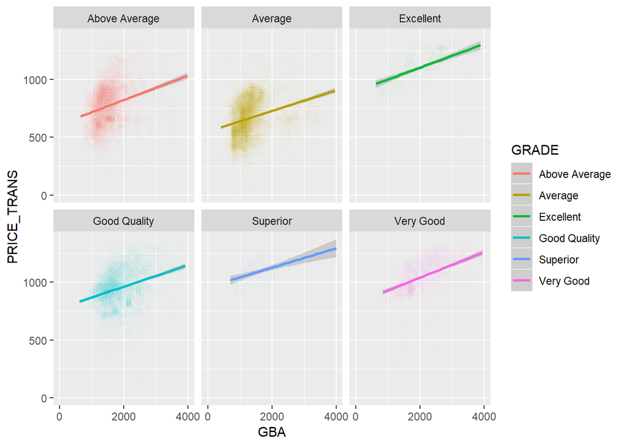

```r
ggplot(house.price[!house.price$GRADE %in%
      c("Exceptional-A", "Exceptional-B", "Fair Quality"), ],
      aes(GBA, PRICE_TRANS, color = GRADE)) +
  geom_point(alpha = 0.05, shape = 1) +
  geom_smooth(method = lm) +
  facet_wrap(~GRADE) +
  scale_x_continuous(limits = c(0, 4000),
                     breaks = seq(0, 4000, 2000))
```

```r
GRADE_median <- house.price %>%
  group_by(GRADE) %>%
  summarise(MEDIAN_PRICE = median(PRICE_TRANS)) %>%
  arrange(MEDIAN_PRICE)
GRADE_median$MEDIAN_PRICE <- round(GRADE_median$MEDIAN_PRICE, digits = 2)

kable(GRADE_median) %>%
  kable_styling(bootstrap_options = c("striped", "hover"), full_width = F)
```

| GRADE | MEDIAN_PRICE |
| --- | --- |
| Fair Quality | 409.13 |
| Average | 663.25 |
| Above Average | 782.62 |
| Exceptional-B | 921.95 |
| Good Quality | 950.53 |
| Very Good | 1067.71 |
| Superior | 1113.55 |
| Excellent | 1140.18 |
| Exceptional-A | 1214.66 |

```r
house.price$GRADE_MEDIAN_PRICE <- lapply(house.price$GRADE, function(x)
  GRADE_median[match(x, GRADE_median$GRADE), "MEDIAN_PRICE"][[1]])
house.price$GRADE_MEDIAN_PRICE <- as.numeric(house.price$GRADE_MEDIAN_PRICE)
house.price <- select(house.price, -GRADE)
```

As seen in the graph and the table, prices are distinctively different by grade. Therefore, these median prices grade by grade would replace the categorical variable “GRADE” rather than grouping them as reduced categories.

## Diagnostic Analysis

Recalling the goal of this project, evaluating linear models is crucial to building the best model. Diagnostic analysis is the step to do that in various ways such as Q-Q plot, Residual vs. Fitted plot, Cook’s distance, and so on. These techniques are designed to test the assumptions like constant variance, normality of residuals, and random error. The first step for this is to build a linear model that will work as baseline and be modified later.

```r
house.lm <- lm(PRICE_TRANS ~ ., data = house.price)
summary(house.lm)
```

```
##
## Call:
## lm(formula = PRICE_TRANS ~ ., data = house.price)
##
## Residuals:
##      Min       1Q   Median       3Q      Max
## -1033.15   -48.89    -1.19    47.75   766.09
##
## Coefficients:
##                      Estimate Std. Error t value Pr(>|t|)
## (Intercept)         7.610e+02  1.503e+02   5.065 4.14e-07 ***
## BATHRM              2.367e+01  1.376e+00  17.195  < 2e-16 ***
## HF_BATHRM           1.989e+01  1.687e+00  11.791  < 2e-16 ***
## ACY                 8.028e+00  2.612e+00   3.074 0.002117 **
## ROOMS              -5.383e-02  6.188e-01  -0.087 0.930682
## BEDRM               4.084e+00  1.214e+00   3.365 0.000768 ***
## AYB                -1.169e+00  5.455e-02 -21.429  < 2e-16 ***
## EYB                 9.887e-01  1.062e-01   9.312  < 2e-16 ***
## STORIES            -4.009e-01  1.662e+00  -0.241 0.809352
## QUALIFIEDU         -9.573e+01  2.363e+00 -40.508  < 2e-16 ***
## GBA                 6.857e-02  2.357e-03  29.092  < 2e-16 ***
## STRUCTExpensive     3.413e+01  2.300e+00  14.839  < 2e-16 ***
## CNDTNGood           3.435e+01  2.583e+00  13.300  < 2e-16 ***
## EXTWALLPremium      5.489e+00  3.490e+00   1.573 0.115761
## ROOFExpensive       1.115e+01  3.351e+00   3.328 0.000877 ***
## FIREPLACES          1.362e+01  1.350e+00  10.085  < 2e-16 ***
## WARDWard 2          8.984e+01  5.515e+00  16.289  < 2e-16 ***
## WARDWard 3          5.428e+01  4.768e+00  11.382  < 2e-16 ***
## WARDWard 4         -6.287e+01  3.984e+00 -15.783  < 2e-16 ***
## WARDWard 5         -8.875e+01  3.925e+00 -22.610  < 2e-16 ***
## WARDWard 6          3.723e+00  3.852e+00   0.966 0.333921
## WARDWard 7         -2.157e+02  4.370e+00 -49.356  < 2e-16 ***
## WARDWard 8         -2.458e+02  4.677e+00 -52.548  < 2e-16 ***
## RMDLY               2.674e+00  2.331e+00   1.147 0.251409
## GRADE_MEDIAN_PRICE  2.443e-01  9.596e-03  25.454  < 2e-16 ***
## ---
## Signif. codes:  0 '***' 0.001 '**' 0.01 '*' 0.05 '.' 0.1 ' ' 1
##
## Residual standard error: 92.86 on 11977 degrees of freedom
## Multiple R-squared:  0.8132, Adjusted R-squared:  0.8128
## F-statistic:  2172 on 24 and 11977 DF,  p-value: < 2.2e-16
```

There are a few variables that are not significant. “ROOMS” must be due to collinearity, and the rest are seemingly because they are not useful. Interestingly enough, “Ward 6” has already been problematic on the map earlier.

### **Diagnostic Plots and Influential Points**

With the baseline model, diagnostic plots can be drawn. Residual vs. Fitted plot should have the balancing line horizontally around zero. The ideal Q-Q plot follows the diagonal line. Cook’s distance is used as limits which dots should not go over. It gives the indice of observations with problems so they can be excluded.

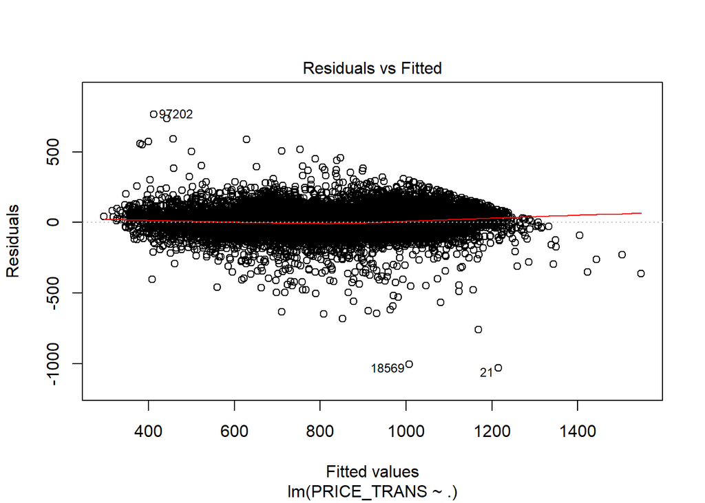

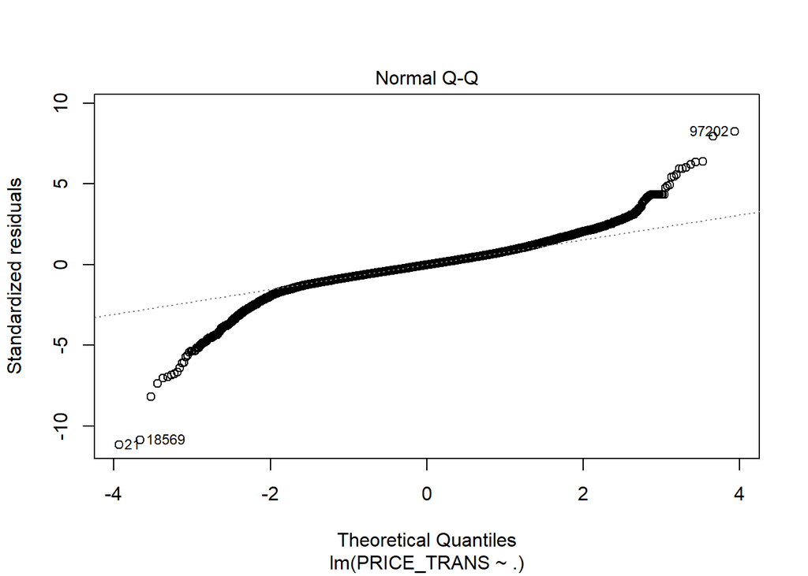

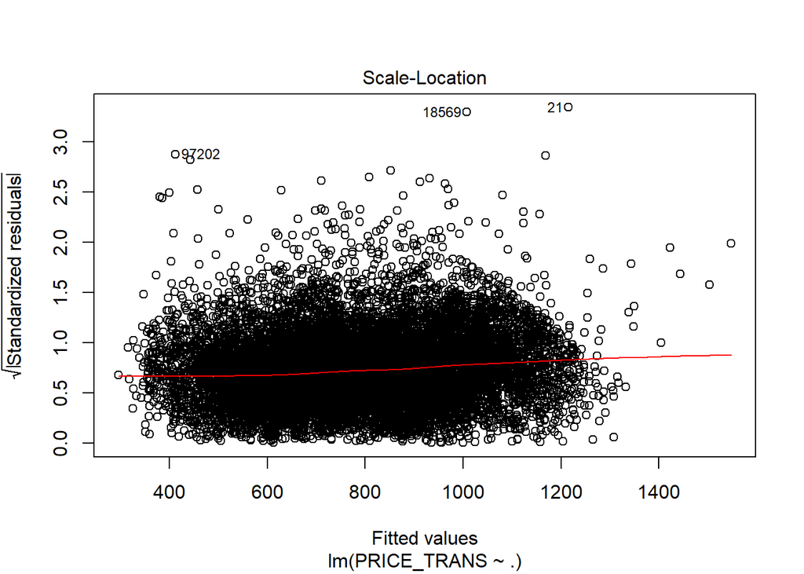

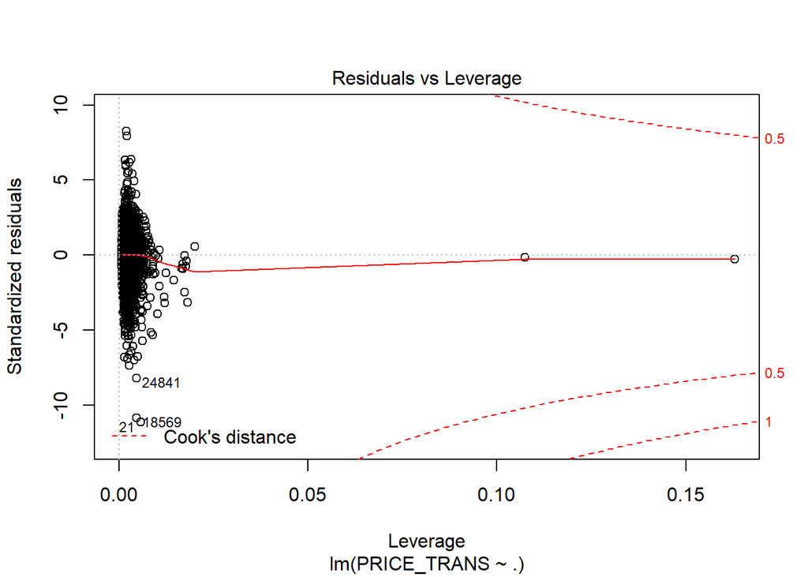

```r
plot(house.lm)
```

```r
# influential observations from Cook's Distance-Leverage
X_y <- names(select_if(house.price, is.numeric))
print(house.price[row.names(house.price) %in%
    c(21, 18569, 24841, 97202), c(X_y)])
```

```
##       BATHRM HF_BATHRM ROOMS BEDRM  AYB  EYB STORIES  GBA FIREPLACES
## 21         3         1    14     5 1880 1987     3.0 3465          3
## 18569      2         1     8     3 1890 1976     2.0 2272          0
## 24841      4         1     7     3 1996 2009     2.5 2480          2
## 97202      1         0     4     1 1915 1954     1.0  684          0
##       PRICE_TRANS GRADE_MEDIAN_PRICE
## 21     182.296462            1067.71
## 18569    3.162278            1113.55
## 24841  409.878031            1067.71
## 97202 1178.982612             663.25
```

```r
# drop influential observations
house.price <- house.price[!row.names(house.price) %in%
    c(21, 18569, 24841, 97202), ]
```

There are four observations that the plots suggest looking closely. They are clearly strangely priced for their features. For example, index 21 has 14 rooms and it’s only 182 unit price when its group median is 1067 unit price. The rest are also deviant from normal pattern.

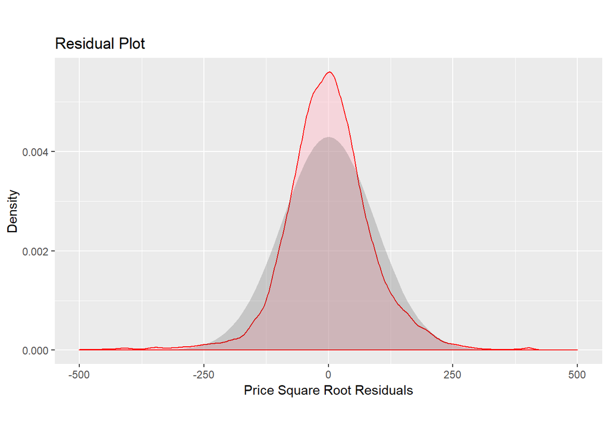

```r
resid.plot <- function(model) {
  ggplot(model, aes(.resid)) +
    geom_density(fill = "pink", color = "red", alpha = 0.5) +
    stat_function(fun = dnorm, args = list(
      mean = mean(resid(model)), sd = sd(resid(model))),
      linetype = "dashed", geom = "area", alpha = 0.2) +
    xlab("Price Square Root Residuals") + ylab("Density") +
    ggtitle("Residual Plot") +
    scale_x_continuous(limits = c(-500, 500)) +
    coord_fixed(ratio = 1e5)
}

resid.plot(house.lm)
```

### **Remove Influential Points: *DFBETA***

One of the methods to detect influential points is *DFBETA* which measures how much impact each observation has on a particular predictor. Recalling the correlation matrix, the top three will be investigated in order to remove influential points. The ultimate goal of this process is again finding the general trend, not biased by extreme values.

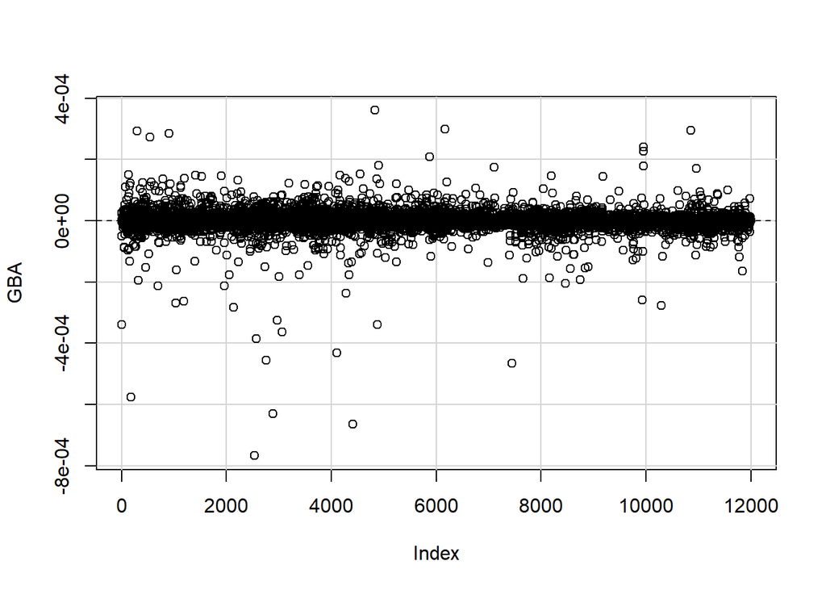

```r
# dfbeta
dfbeta.GBA <- dfbetaPlots(house.lm, terms = "GBA")
```

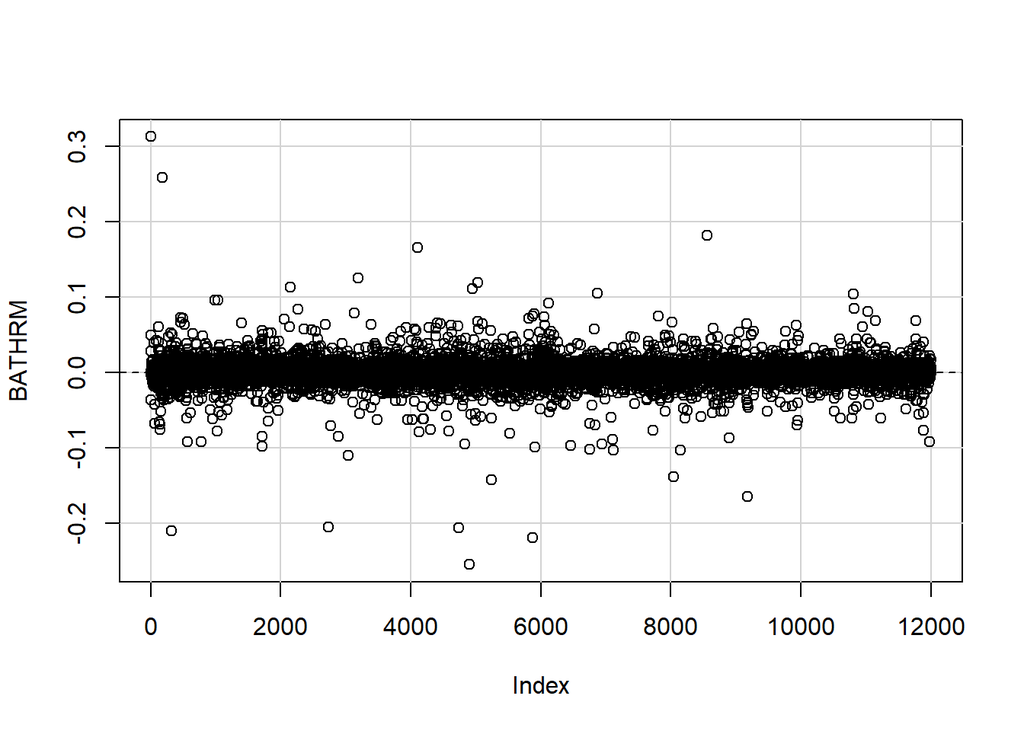

```r
dfbeta.BATHRM <- dfbetaPlots(house.lm, terms = "BATHRM")
```

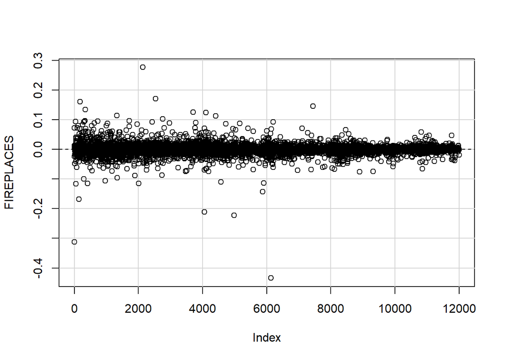

```r
dfbeta.FIREPLACES <- dfbetaPlots(house.lm, terms = "FIREPLACES")
```

“GBA”, “BATHRM”, and “FIREPLACES” are the top three correlated variables. Because they will affect house prices the most, influential points should be detected based on them. The following calculates DFBETA’s and threshold for the data set, and finds influential points with the three features.

$$Threshold=\frac{2}{\sqrt{n}}\ where\ n=observations$$

```r
# calculate dfbetas for selected variables
dfbeta.thrhd <- as.numeric(sqrt(4/count(house.price)))
dfbetas <- dfbetas(house.lm)
cat("DFBETA limit:", dfbeta.thrhd)
```

```
## DFBETA limit: 0.01825894
```

```r
# influential point indice
dfbetas.infl.obs <- names(dfbetas[abs(dfbetas[ , "GBA"])
                                  > dfbeta.thrhd, "GBA"])
dfbetas.infl.obs <- c(dfbetas.infl.obs,
                      names(dfbetas[abs(dfbetas[ , "BATHRM"])
                                  > dfbeta.thrhd, "BATHRM"]))
dfbetas.infl.obs <- c(dfbetas.infl.obs,
                      names(dfbetas[abs(dfbetas[ , "FIREPLACES"])
                                  > dfbeta.thrhd, "FIREPLACES"]))

# filter observations over dfbeta limit
house.price <- house.price[!row.names(house.price) %in% dfbetas.infl.obs, ]
```

```r
house.infl.lm <- lm(PRICE_TRANS ~., data = house.price)
summary(house.infl.lm)
```

```
##
## Call:
## lm(formula = PRICE_TRANS ~ ., data = house.price)
##
## Residuals:
##     Min      1Q  Median      3Q     Max
## -466.85  -43.51   -1.04   40.47  544.05
##
## Coefficients:
##                      Estimate Std. Error t value Pr(>|t|)
## (Intercept)         6.651e+02  1.153e+02   5.767 8.28e-09 ***
## BATHRM              2.481e+01  1.124e+00  22.072  < 2e-16 ***
## HF_BATHRM           1.991e+01  1.316e+00  15.125  < 2e-16 ***
## ACY                 8.312e+00  1.993e+00   4.171 3.05e-05 ***
## ROOMS              -4.748e-01  4.962e-01  -0.957 0.338653
## BEDRM               5.246e+00  9.690e-01   5.414 6.31e-08 ***
## AYB                -1.203e+00  4.323e-02 -27.831  < 2e-16 ***
## EYB                 1.061e+00  8.227e-02  12.898  < 2e-16 ***
## STORIES             9.766e-01  1.250e+00   0.782 0.434494
## QUALIFIEDU         -7.831e+01  1.875e+00 -41.760  < 2e-16 ***
## GBA                 7.230e-02  2.077e-03  34.813  < 2e-16 ***
## STRUCTExpensive     3.292e+01  1.742e+00  18.902  < 2e-16 ***
## CNDTNGood           3.277e+01  1.980e+00  16.549  < 2e-16 ***
## EXTWALLPremium      3.696e-01  2.719e+00   0.136 0.891884
## ROOFExpensive       9.263e+00  2.626e+00   3.528 0.000421 ***
## FIREPLACES          1.490e+01  1.207e+00  12.341  < 2e-16 ***
## WARDWard 2          1.015e+02  4.449e+00  22.805  < 2e-16 ***
## WARDWard 3          6.428e+01  3.709e+00  17.330  < 2e-16 ***
## WARDWard 4         -5.428e+01  3.087e+00 -17.587  < 2e-16 ***
## WARDWard 5         -7.815e+01  3.061e+00 -25.532  < 2e-16 ***
## WARDWard 6          4.901e+00  3.006e+00   1.630 0.103099
## WARDWard 7         -2.095e+02  3.388e+00 -61.847  < 2e-16 ***
## WARDWard 8         -2.351e+02  3.607e+00 -65.190  < 2e-16 ***
## RMDLY               3.035e+00  1.785e+00   1.700 0.089117 .
## GRADE_MEDIAN_PRICE  2.430e-01  7.571e-03  32.094  < 2e-16 ***
## ---
## Signif. codes:  0 '***' 0.001 '**' 0.01 '*' 0.05 '.' 0.1 ' ' 1
##
## Residual standard error: 66.8 on 10660 degrees of freedom
## Multiple R-squared:  0.891,  Adjusted R-squared:  0.8907
## F-statistic:  3630 on 24 and 10660 DF,  p-value: < 2.2e-16
```

After influential points are removed, R-squared is remarkably improved to 0.89 from 0.81. However, there are still insignificant features, so the last step becomes dropping them. These are what the model sees no difference whether they are in the model or not, therefore, R-squared should stay the same after losing them. Other than them, “ROOF” is relatively weaker than the rest. “WARD 6” is one of the values of “WARD”, and this will be handled before building a predictive model.

```r
# drop insignificant regressors
house.price <- select(house.price, -c("ROOMS", "STORIES", "EXTWALL", "RMDL"))
write.csv(house.price, file = "DC_Properties_final.csv", row.names = F)

# regression with significant variables
house.final.lm <- lm(PRICE_TRANS ~ ., data = house.price)
summary(house.final.lm)
```

```
##
## Call:
## lm(formula = PRICE_TRANS ~ ., data = house.price)
##
## Residuals:
##     Min      1Q  Median      3Q     Max
## -466.55  -43.35   -0.93   40.45  544.40
##
## Coefficients:
##                      Estimate Std. Error t value Pr(>|t|)
## (Intercept)         6.982e+02  1.110e+02   6.292 3.25e-10 ***
## BATHRM              2.478e+01  1.083e+00  22.871  < 2e-16 ***
## HF_BATHRM           1.992e+01  1.314e+00  15.160  < 2e-16 ***
## ACY                 9.162e+00  1.939e+00   4.726 2.32e-06 ***
## BEDRM               4.992e+00  9.271e-01   5.385 7.41e-08 ***
## AYB                -1.230e+00  4.042e-02 -30.426  < 2e-16 ***
## EYB                 1.071e+00  8.181e-02  13.093  < 2e-16 ***
## QUALIFIEDU         -7.852e+01  1.871e+00 -41.969  < 2e-16 ***
## GBA                 7.161e-02  1.909e-03  37.507  < 2e-16 ***
## STRUCTExpensive     3.286e+01  1.728e+00  19.018  < 2e-16 ***
## CNDTNGood           3.386e+01  1.879e+00  18.019  < 2e-16 ***
## ROOFExpensive       9.258e+00  2.621e+00   3.532 0.000415 ***
## FIREPLACES          1.495e+01  1.203e+00  12.430  < 2e-16 ***
## WARDWard 2          1.013e+02  4.442e+00  22.803  < 2e-16 ***
## WARDWard 3          6.396e+01  3.665e+00  17.448  < 2e-16 ***
## WARDWard 4         -5.441e+01  3.059e+00 -17.785  < 2e-16 ***
## WARDWard 5         -7.819e+01  3.046e+00 -25.673  < 2e-16 ***
## WARDWard 6          4.768e+00  2.999e+00   1.590 0.111878
## WARDWard 7         -2.094e+02  3.354e+00 -62.446  < 2e-16 ***
## WARDWard 8         -2.353e+02  3.571e+00 -65.876  < 2e-16 ***
## GRADE_MEDIAN_PRICE  2.431e-01  7.523e-03  32.319  < 2e-16 ***
## ---
## Signif. codes:  0 '***' 0.001 '**' 0.01 '*' 0.05 '.' 0.1 ' ' 1
##
## Residual standard error: 66.8 on 10664 degrees of freedom
## Multiple R-squared:  0.8909, Adjusted R-squared:  0.8907
## F-statistic:  4356 on 20 and 10664 DF,  p-value: < 2.2e-16
```

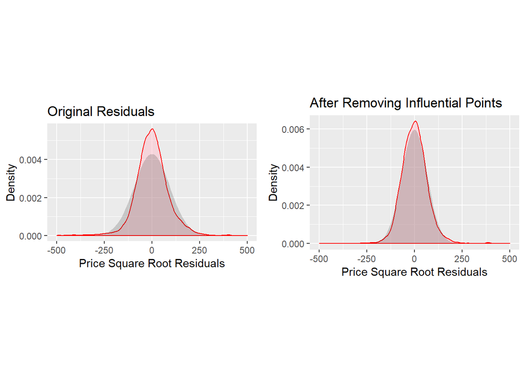

```r
grid.arrange(resid.plot(house.lm) + ggtitle("Original Residuals"),
             resid.plot(house.infl.lm) + ggtitle("After Removing Influential Points"),
             ncol = 2)
```

On the left is before eliminating the influential points and on the right is after that. The assumption of normal residuals is better met with the influential points removed, almost being identical with the normal distribution in gray.

## Best Model

Although there are many other measurements to select features, two representative are used for this project. One is Adjusted R-squared to measure the overall fit, and the other is AIC to see if adding another feature is helpful for modeling.

### **Adjusted R-Square**

```r
# full linear model
rsq.lm <- lm(PRICE_TRANS ~ ., data = house.price)

# convert it to matrix
x <- model.matrix(rsq.lm)[, -1]
y <- house.price$PRICE_TRANS

# 5 best models by adjusted r-squared
adjr <- leaps(x, y, method = "adjr2")
maxadjr(adjr, 5)
```

```
## 1,2,3,4,5,6,7,8,9,10,11,12,13,14,15,16,17,18,19,20
##                                              0.891
##    1,2,3,4,5,6,7,8,9,10,11,12,13,14,15,16,18,19,20
##                                              0.891
##    1,2,3,4,5,6,7,8,9,10,12,13,14,15,16,17,18,19,20
##                                              0.891
##       1,2,3,4,5,6,7,8,9,10,12,13,14,15,16,18,19,20
##                                              0.891
##   1,2,4,5,6,7,8,9,10,11,12,13,14,15,16,17,18,19,20
##                                              0.891
```

The result of 5 best models indicates predictor numbers and adjusted r-squared for each model. While all the models perform the same (0.89), they have different set of predictors. Since a simpler model is bettern for the same performance, the 4th should be chosen with the least number of features.

```r
print(colnames(x[, c(11, 17)]))
```

```
## [1] "ROOFExpensive" "WARDWard 6"
```

```r
x <- x[, -c(11, 17)]
```

The two features the 4th model excludes happen to be what already had issues on significance. Now that it is clear they do not need to be in the model, “ROOF” and “WARD 6” can be let go. Nevertheless, it is safe to see feature selection at a different angle.

### **AIC**

Basically, AIC is designed to decide whether to include an additinal variable or not. The lower the score is, the better the model is. The process runs through features and calculate AIC and continue until AIC stops decreasing. The following starts with a null model and add a feature one by one to see how AIC changes.

```r
# null model for variable addition
null.lm <- lm(PRICE_TRANS ~ 1, data = house.price)
full.lm <- lm(PRICE_TRANS ~ ., data = house.price)

# stepwise selection
step(null.lm, scope = list(lower = null.lm, upper = full.lm),
     direction = "both")
```

```
## Start:  AIC=113448.5
## PRICE_TRANS ~ 1
##
##                      Df Sum of Sq       RSS    AIC
## + WARD                7 280357353 155994622 102472
## + GRADE_MEDIAN_PRICE  1 209347790 227004185 106468
## + GBA                 1 127386145 308965830 109762
## + FIREPLACES          1 121626952 314725023 109959
## + BATHRM              1  98008564 338343411 110732
## + BEDRM               1  58669252 377682723 111908
## + QUALIFIED           1  47450012 388901963 112220
## + STRUCT              1  43602660 392749315 112326
## + CNDTN               1  40578184 395773791 112408
## + HF_BATHRM           1  33346273 403005702 112601
## + AYB                 1  33215069 403136906 112605
## + ROOF                1  27149644 409202331 112764
## + AC                  1  25692455 410659520 112802
## + EYB                 1  18547356 417804619 112986
## <none>                            436351975 113449
##
## Step:  AIC=102471.6
## PRICE_TRANS ~ WARD
##
##                      Df Sum of Sq       RSS    AIC
## + GBA                 1  53904968 102089653  97944
## + BATHRM              1  49887222 106107400  98356
## + GRADE_MEDIAN_PRICE  1  44064741 111929881  98927
## + BEDRM               1  33110405 122884217  99924
## + CNDTN               1  26333572 129661050 100498
## + EYB                 1  23263095 132731526 100748
## + FIREPLACES          1  20577094 135417527 100962
## + QUALIFIED           1  20035415 135959207 101005
## + AC                  1  17124704 138869918 101231
## + HF_BATHRM           1  12797291 143197331 101559
## + STRUCT              1   6563659 149430963 102014
## + ROOF                1   3748826 152245796 102214
## + AYB                 1    401705 155592917 102446
## <none>                            155994622 102472
## - WARD                7 280357353 436351975 113449
##
```

[output cut: 255 more lines]

```
## <none>                             47589300 89812
## - ROOF                1     55664  47644964 89823
## - AC                  1     99660  47688960 89833
## - BEDRM               1    129399  47718698 89839
## - FIREPLACES          1    689541  48278841 89964
## - EYB                 1    765049  48354348 89981
## - HF_BATHRM           1   1025557  48614857 90038
## - CNDTN               1   1448874  49038174 90131
## - STRUCT              1   1613975  49203275 90167
## - BATHRM              1   2334329  49923629 90322
## - AYB                 1   4131116  51720416 90700
## - GRADE_MEDIAN_PRICE  1   4661249  52250548 90809
## - GBA                 1   6277879  53867179 91134
## - QUALIFIED           1   7860573  55449872 91444
## - WARD                7  55284755 102874055 98035
```

```
##
## Call:
## lm(formula = PRICE_TRANS ~ WARD + GBA + CNDTN + GRADE_MEDIAN_PRICE +
##     QUALIFIED + AYB + BATHRM + STRUCT + HF_BATHRM + EYB + FIREPLACES +
##     BEDRM + AC + ROOF, data = house.price)
##
## Coefficients:
##        (Intercept)          WARDWard 2          WARDWard 3
##          698.16080           101.28301            63.95630
##         WARDWard 4          WARDWard 5          WARDWard 6
##          -54.41096           -78.18838             4.76844
##         WARDWard 7          WARDWard 8                 GBA
##         -209.41612          -235.26479             0.07161
##          CNDTNGood  GRADE_MEDIAN_PRICE          QUALIFIEDU
##           33.86244             0.24312           -78.51845
##                AYB              BATHRM     STRUCTExpensive
##           -1.22984            24.77822            32.85632
##          HF_BATHRM                 EYB          FIREPLACES
##           19.91879             1.07114            14.95291
##              BEDRM                 ACY       ROOFExpensive
##            4.99228             9.16163             9.25816
```

As the result shows, the full model has the lowest AIC, meaning that adding all the features is the best. However, we know “ROOF” and “WARD 6” would not make any difference, thus, they can be removed. Still, the feature selection is in accordance with the Adjusted R-squared and AIC results.

## Prediction

A predictive model can be used to predict a house price for one purpose, and to see if a house value is evaluated properly for another. The principle steps start with splitting data set, train one part, and test the model against the rest. Since training set and testing set could be biased, partitioning should loop through the data set (Cross Validation).

```r
# data frame for prediction
price.df <- data.frame(x, y)

# hold 30% for validation
train.indice <- createDataPartition(price.df$y, p = 0.7, list = F)
training.set <- price.df[train.indice, ]
testing.set <- price.df[-train.indice, ]

# cross validation
train.control <- trainControl(method = "repeatedcv", number = 5, repeats = 3)
lm.model <- train(y ~ ., data = price.df, trControl = train.control, method = "lm")
summary(lm.model)
```

```
##
## Call:
## lm(formula = .outcome ~ ., data = dat)
##
## Residuals:
##     Min      1Q  Median      3Q     Max
## -466.25  -43.10   -1.17   40.51  543.80
##
## Coefficients:
##                      Estimate Std. Error t value Pr(>|t|)
## (Intercept)         763.86590  109.74435   6.960 3.59e-12 ***
## BATHRM               24.81960    1.08399  22.897  < 2e-16 ***
## HF_BATHRM            20.09576    1.31399  15.294  < 2e-16 ***
## ACY                   9.52283    1.93769   4.915 9.03e-07 ***
## BEDRM                 4.84664    0.92349   5.248 1.57e-07 ***
## AYB                  -1.21242    0.04018 -30.172  < 2e-16 ***
## EYB                   1.02048    0.08083  12.625  < 2e-16 ***
## QUALIFIEDU          -78.50728    1.87148 -41.949  < 2e-16 ***
## GBA                   0.07181    0.00191  37.604  < 2e-16 ***
## STRUCTExpensive      33.16673    1.72692  19.206  < 2e-16 ***
## CNDTNGood            34.35376    1.87601  18.312  < 2e-16 ***
## FIREPLACES           15.56695    1.19340  13.044  < 2e-16 ***
## WARDWard.2           97.12006    3.95214  24.574  < 2e-16 ***
## WARDWard.3           61.87410    3.00451  20.594  < 2e-16 ***
## WARDWard.4          -56.78342    2.21129 -25.679  < 2e-16 ***
## WARDWard.5          -81.42730    2.20527 -36.924  < 2e-16 ***
## WARDWard.7         -212.63356    2.56912 -82.765  < 2e-16 ***
## WARDWard.8         -238.45803    2.87632 -82.904  < 2e-16 ***
## GRADE_MEDIAN_PRICE    0.24693    0.00743  33.234  < 2e-16 ***
## ---
## Signif. codes:  0 '***' 0.001 '**' 0.01 '*' 0.05 '.' 0.1 ' ' 1
##
## Residual standard error: 66.84 on 10666 degrees of freedom
## Multiple R-squared:  0.8908, Adjusted R-squared:  0.8906
## F-statistic:  4833 on 18 and 10666 DF,  p-value: < 2.2e-16
```

The result is not very different from the initial modeling, claiming that the prediction model performs well. All the variables are now significant, and Adjusted R-squared is very slightly lower than R-squared. Putting them altogether, there is no more feature to be eliminated. One last step is to see how well this model works.

### **Evaluation: *RMSE***

```r
price_pred <- predict(lm.model, newdata = testing.set)

rmse <- RMSE(testing.set$y, price_pred)
cat("Root Mean Square Error (RMSE):", rmse)
```

```
## Root Mean Square Error (RMSE): 67.85566
```

```r
True.Price <- (testing.set$y)^2
Predicted.Price <- price_pred^2
pred.df <- data.frame(True.Price, Predicted.Price)
pred.df$Diff <- pred.df$True.Price - pred.df$Predicted.Price

kable(head(pred.df, n = 20)) %>%
  kable_styling() %>%
  scroll_box(width = "500px", height = "500px")
```

|  | True.Price | Predicted.Price | Diff |
| --- | --- | --- | --- |
| 161 | 830000 | 886218.6 | -56218.571 |
| 237 | 915000 | 969096.4 | -54096.369 |
| 283 | 875000 | 742537.4 | 132462.612 |
| 311 | 800000 | 825870.1 | -25870.093 |
| 370 | 1250000 | 1132902.5 | 117097.548 |
| 385 | 599100 | 918343.7 | -319243.661 |
| 422 | 1000000 | 1008222.9 | -8222.879 |
| 426 | 1180000 | 1087103.7 | 92896.323 |
| 523 | 1370000 | 1365901.5 | 4098.482 |
| 560 | 805000 | 942926.6 | -137926.600 |
| 573 | 1155200 | 880105.2 | 275094.763 |
| 574 | 1037500 | 880105.2 | 157394.763 |
| 648 | 1412500 | 1434301.9 | -21801.915 |
| 664 | 815000 | 682406.0 | 132593.966 |
| 706 | 1000000 | 864038.4 | 135961.588 |
| 714 | 1505000 | 1554302.7 | -49302.671 |
| 805 | 1720000 | 1699255.1 | 20744.886 |
| 819 | 1600000 | 1552499.1 | 47500.888 |
| 921 | 635000 | 846595.9 | -211595.908 |
| 964 | 801600 | 765697.9 | 35902.051 |

```r
cat("True Price vs. Predicted Price\n",
    "Mean Error: $", mean(abs(pred.df$Diff)), '\n',
    "Median Error: $", median(abs(pred.df$Diff)))
```

```
## True Price vs. Predicted Price
##  Mean Error: $ 81393.75
##  Median Error: $ 63025.38
```

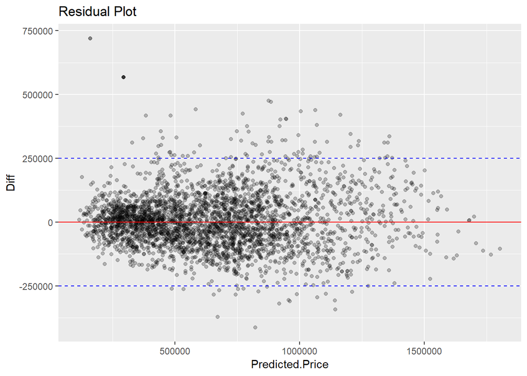

```r
ggplot(pred.df, aes(Predicted.Price, Diff)) +
  geom_point(alpha = 0.25) +
  geom_hline(yintercept = 0, color = 'red') +
  geom_hline(yintercept = c(-250000, 250000), color = 'blue', linetype = "dashed") +
  ggtitle("Residual Plot")
```

```r
mean_price <- pred.df[pred.df$True.Price > 650000 &
                        pred.df$True.Price < 660000, "Predicted.Price"]
median_price <- pred.df[pred.df$True.Price > 615000 &
                          pred.df$True.Price < 625000, "Predicted.Price"]

cat("Mean and Median Price Prediction\n",
    "Mean (650K~660K): $", mean(abs(mean_price)), '\n',
    "Median (615K~625K): $", mean(abs(median_price)))
```

```
## Mean and Median Price Prediction
##  Mean (650K~660K): $ 669352.3
##  Median (615K~625K): $ 582964.1
```

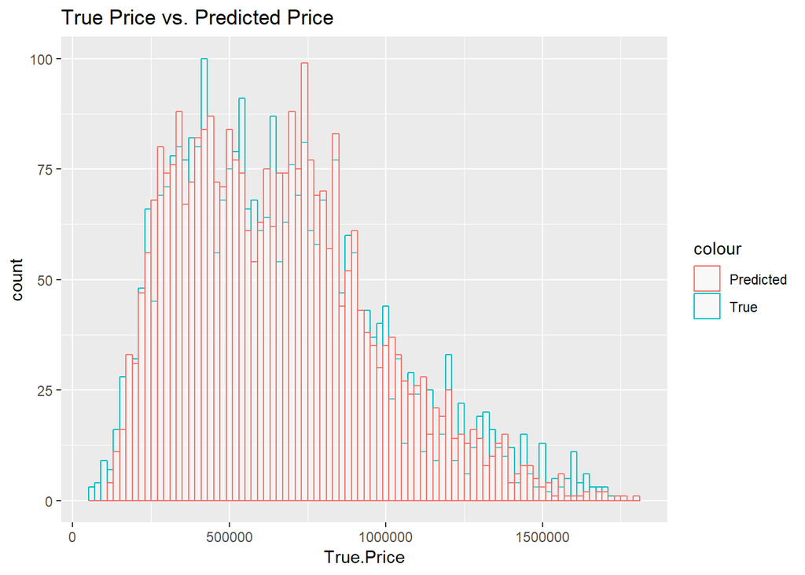

```r
ggplot(pred.df) +
  geom_histogram(aes(True.Price, color="True"),
                 binwidth = 20000, fill = "white", alpha = 0.25) +
  geom_histogram(aes(Predicted.Price, color="Predicted"),
                 binwidth = 20000, fill = "white", alpha = 0.25) +
  ggtitle("True Price vs. Predicted Price")
```

Finally, histograms of true values and predicted values can be drawn together to see how similar they are over the price ranges. During the analysis, we found out that the distributions had issues on tails. The same occurs here where most of errors occur on tails. However, this shouldn’t be a serious problem because the model is focused on majority of houses, not overly expensive or cheap houses.

## References

[kable](https://cran.r-project.org/web/packages/kableExtra/vignettes/awesome_table_in_html.html) [Mapping](http://eriqande.github.io/rep-res-web/lectures/making-maps-with-R.html#) [ggmap Github](https://github.com/dkahle/ggmap) [ggmap stamen](https://rdrr.io/cran/ggmap/man/get_stamenmap.html) [corrplot](https://cran.r-project.org/web/packages/corrplot/vignettes/corrplot-intro.html) [type of apply](https://www.guru99.com/r-apply-sapply-tapply.html) [Linear Regression Example](http://r-statistics.co/Linear-Regression.html) Scatter Plot [Outlier](https://www.r-bloggers.com/outlier-detection-and-treatment-with-r/) [Boxplot](http://www.sthda.com/english/wiki/ggplot2-box-plot-quick-start-guide-r-software-and-data-visualization) [VIF](http://www.scriptwarp.com/warppls/pubs/Kock_Lynn_2012.pdf) [leaps](https://rdrr.io/cran/leaps/man/regsubsets.html) [Diagnosis & Variable Selection](https://www.statmethods.net/stats/regression.html) [Q-Q Plot Interpretation](https://stats.stackexchange.com/questions/101274/how-to-interpret-a-qq-plot) [Diagnostic Plots](https://data.library.virginia.edu/diagnostic-plots/)